# Cx4073 : Assignment 1

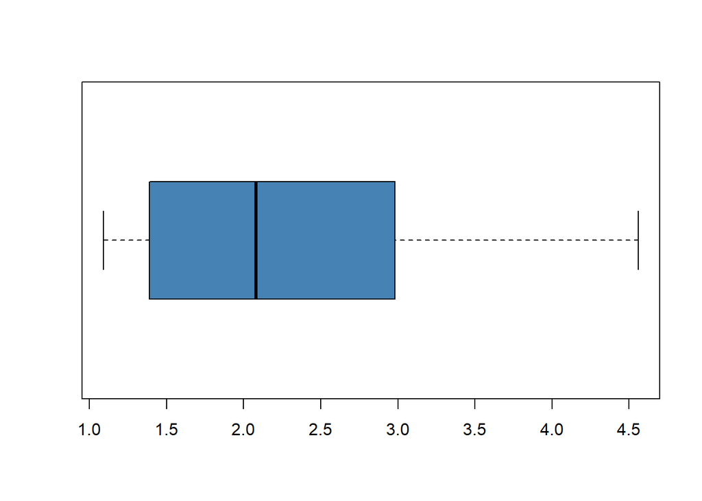

```r
boxplot(navalData$X11, horizontal = TRUE, col = "steelblue")
```

X12 : GT Compressor inlet air pressure (P1) [bar]

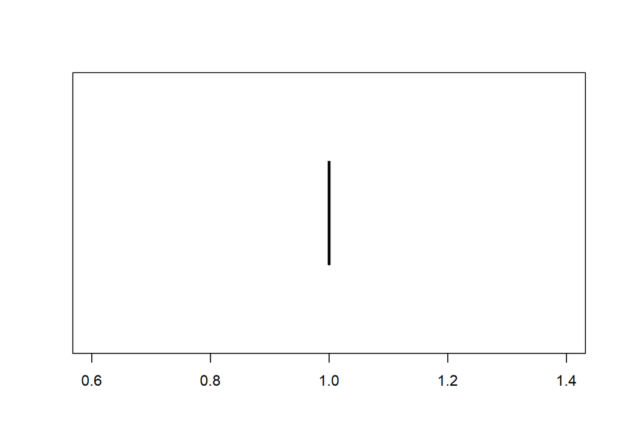

```r
boxplot(navalData$X12, horizontal = TRUE, col = "steelblue")
```

X13 : GT Compressor outlet air pressure (P2) [bar]

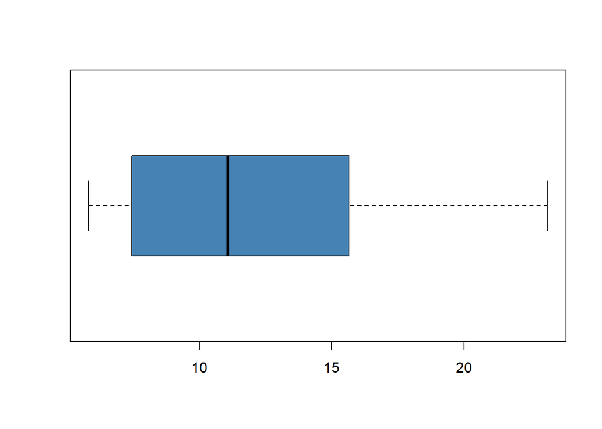

```r
boxplot(navalData$X13, horizontal = TRUE, col = "steelblue")
```

X14 : Gas Turbine exhaust gas pressure (Pexh) [bar]

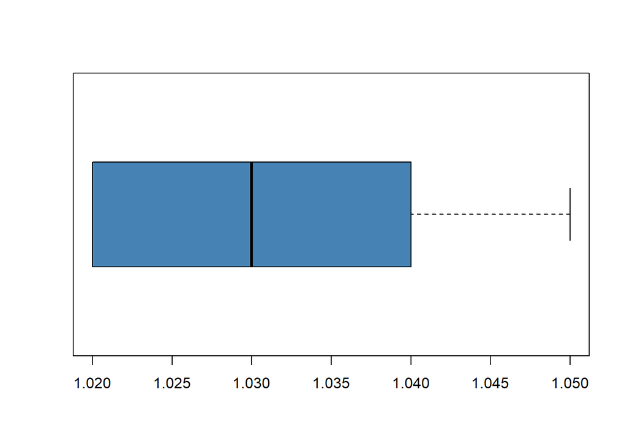

```r
boxplot(navalData$X14, horizontal = TRUE, col = "steelblue")
```

X15 : Turbine Injecton Control (TIC) [%]

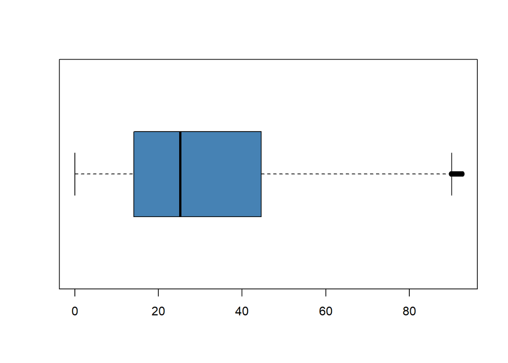

```r
boxplot(navalData$X15, horizontal = TRUE, col = "steelblue")
```

X16 : Fuel flow (mf) [kg/s]

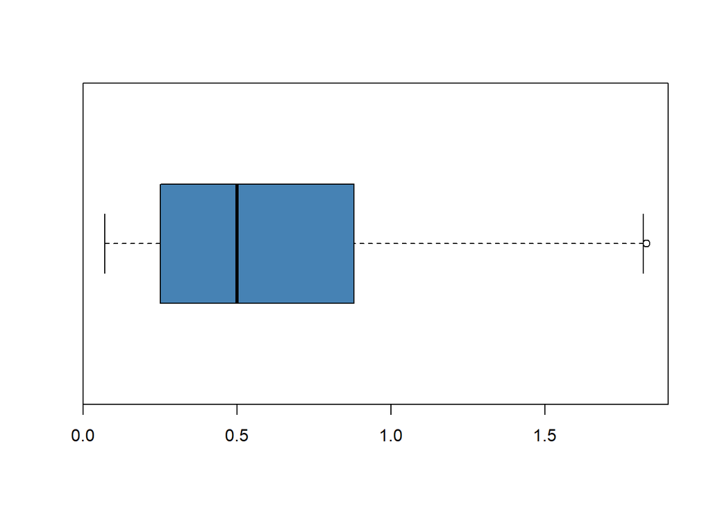

```r
boxplot(navalData$X16, horizontal = TRUE, col = "steelblue")
```

Y1 : GT Compressor decay state coefficient

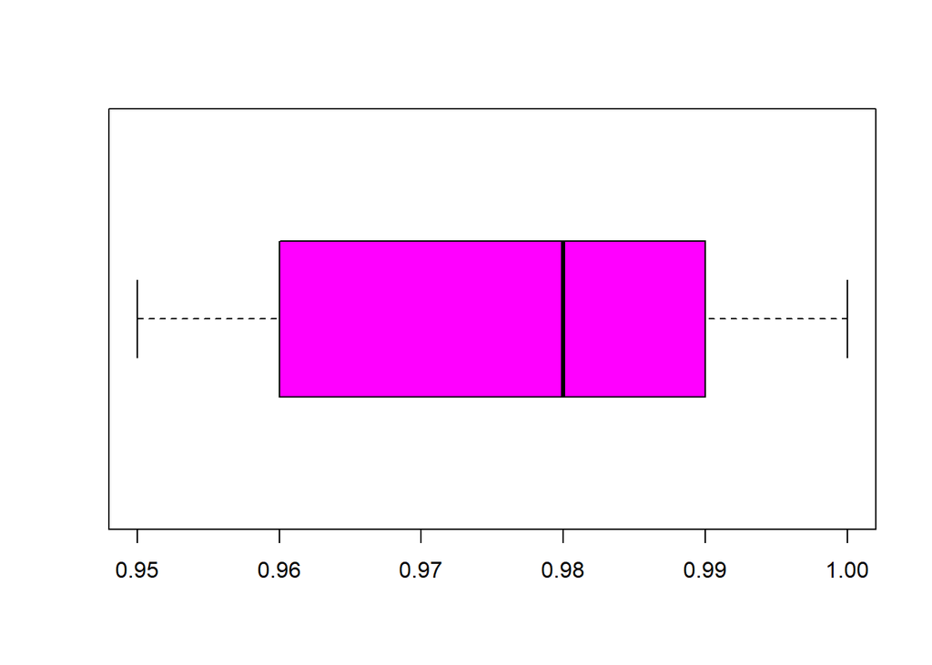

```r
boxplot(navalData$Y1, horizontal = TRUE, col = "magenta")
```

Y2 : GT Turbine decay state coefficient

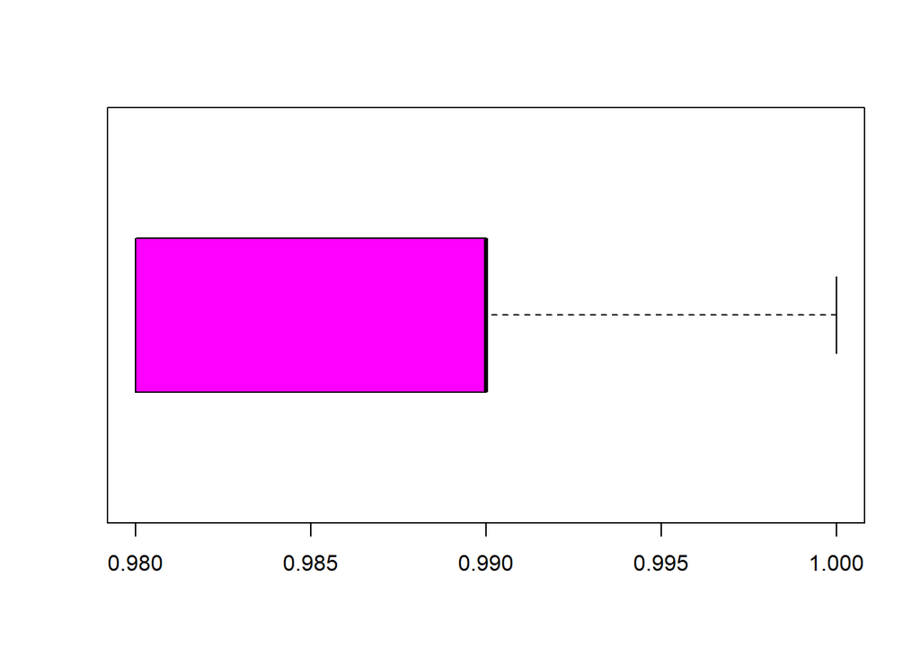

```r
boxplot(navalData$Y2, horizontal = TRUE, col = "magenta")
```

**Some key observations**: The values of `X6` and `X7` are identical. Therefore, we can consider removing either of them as we do not require duplicate data.

Statistical summary for all variables in loaded dataset

```r
summary(navalData)
```

```
##        X1              X2              X3                X4
##  Min.   :1.140   Min.   : 3.00   Min.   :  253.6   Min.   :1308
##  1st Qu.:3.140   1st Qu.: 9.00   1st Qu.: 8375.9   1st Qu.:1387
##  Median :5.140   Median :15.00   Median :21630.7   Median :1924
##  Mean   :5.162   Mean   :14.98   Mean   :27160.0   Mean   :2134
##  3rd Qu.:7.150   3rd Qu.:21.00   3rd Qu.:39001.2   3rd Qu.:2678
##  Max.   :9.300   Max.   :27.00   Max.   :72783.3   Max.   :3561
##        X5             X6               X7               X8
##  Min.   :6589   Min.   :  5.30   Min.   :  5.30   Min.   : 444.7
##  1st Qu.:7058   1st Qu.: 60.32   1st Qu.: 60.32   1st Qu.: 590.0
##  Median :8482   Median :175.27   Median :175.27   Median : 706.0
##  Mean   :8198   Mean   :226.51   Mean   :226.51   Mean   : 734.9
##  3rd Qu.:9132   3rd Qu.:332.36   3rd Qu.:332.36   3rd Qu.: 833.6
##  Max.   :9797   Max.   :645.25   Max.   :645.25   Max.   :1115.8
##        X9           X10             X11             X12         X13
##  Min.   :288   Min.   :541.0   Min.   :1.090   Min.   :1   Min.   : 5.83
##  1st Qu.:288   1st Qu.:578.1   1st Qu.:1.390   1st Qu.:1   1st Qu.: 7.45
##  Median :288   Median :637.1   Median :2.080   Median :1   Median :11.09
##  Mean   :288   Mean   :646.0   Mean   :2.349   Mean   :1   Mean   :12.28
##  3rd Qu.:288   3rd Qu.:693.8   3rd Qu.:2.980   3rd Qu.:1   3rd Qu.:15.66
##  Max.   :288   Max.   :789.1   Max.   :4.560   Max.   :1   Max.   :23.14
##       X14            X15             X16               Y1
##  Min.   :1.02   Min.   : 0.00   Min.   :0.0700   Min.   :0.9500
##  1st Qu.:1.02   1st Qu.:14.12   1st Qu.:0.2500   1st Qu.:0.9600
##  Median :1.03   Median :25.27   Median :0.5000   Median :0.9800
##  Mean   :1.03   Mean   :33.56   Mean   :0.6607   Mean   :0.9757
##  3rd Qu.:1.04   3rd Qu.:44.53   3rd Qu.:0.8800   3rd Qu.:0.9900
##  Max.   :1.05   Max.   :92.56   Max.   :1.8300   Max.   :1.0000
##        Y2
##  Min.   :0.9800
##  1st Qu.:0.9800
##  Median :0.9900
##  Mean   :0.9885
##  3rd Qu.:0.9900
##  Max.   :1.0000
```

It returns a table with the results of the summary function being applied to each variable in the loaded dataset. It shows the Min, Median, Mean, Max, 1st and 3rd Quartile.

For a more compressed view of the loaded dataset, we can use the function `glimpse()`.

```r
glimpse(navalData)
```

```
## Observations: 10,000
## Variables: 18
## $ X1  <dbl> 3.14, 7.15, 5.14, 4.16, 9.30, 9.30, 2.09, 1.14, 8.21, 8.21, 9.3...
## $ X2  <int> 9, 21, 15, 12, 27, 27, 6, 3, 24, 24, 27, 21, 21, 3, 27, 9, 9, 2...
## $ X3  <dbl> 8373.85, 39007.12, 21639.19, 14721.84, 72759.21, 72763.86, 6948...
## $ X4  <dbl> 1386.72, 2678.01, 1924.36, 1547.46, 3560.37, 3560.39, 1373.84, ...
## $ X5  <dbl> 7013.62, 9116.04, 8513.72, 7757.85, 9729.10, 9755.85, 6795.34, ...
## $ X6  <dbl> 60.28, 332.49, 175.32, 113.78, 644.74, 644.76, 27.73, 7.32, 437...
## $ X7  <dbl> 60.28, 332.49, 175.32, 113.78, 644.74, 644.76, 27.73, 7.32, 437...
## $ X8  <dbl> 585.98, 821.74, 705.11, 653.07, 1057.88, 1086.81, 600.10, 587.4...
## $ X9  <int> 288, 288, 288, 288, 288, 288, 288, 288, 288, 288, 288, 288, 288...
## $ X10 <dbl> 578.07, 686.53, 640.12, 610.15, 771.58, 780.50, 570.40, 562.73,...
## $ X11 <dbl> 1.39, 2.99, 2.07, 1.66, 4.55, 4.52, 1.33, 1.26, 3.60, 3.58, 4.5...
## $ X12 <int> 1, 1, 1, 1, 1, 1, 1, 1, 1, 1, 1, 1, 1, 1, 1, 1, 1, 1, 1, 1, 1, ...
## $ X13 <dbl> 7.60, 15.71, 10.92, 9.01, 22.96, 22.85, 7.14, 6.81, 18.56, 18.6...
## $ X14 <dbl> 1.02, 1.04, 1.03, 1.02, 1.05, 1.05, 1.02, 1.02, 1.04, 1.04, 1.0...
## $ X15 <dbl> 12.35, 43.97, 24.89, 17.77, 88.27, 90.41, 10.18, 19.86, 59.61, ...
## $ X16 <dbl> 0.24, 0.87, 0.49, 0.35, 1.75, 1.79, 0.26, 0.25, 1.18, 1.22, 1.7...
## $ Y1  <dbl> 0.99, 0.99, 0.95, 0.97, 1.00, 0.97, 0.99, 0.99, 1.00, 0.96, 1.0...
## $ Y2  <dbl> 0.98, 0.98, 1.00, 0.98, 0.98, 0.98, 1.00, 0.99, 0.99, 0.98, 0.9...
```

It shows the number of rows, variables, variable type, name as well as the values in each variable.

### Advanced Exploration of CSV file

Since we loaded the dataset at the start of the assignment, we can view the correlation plot of all variables.

```r
cor(navalData)
```

```
## Warning in cor(navalData): the standard deviation is zero
```

```
##               X1           X2           X3           X4           X5
## X1   1.000000000  0.999918932  0.961060859  0.962170527  0.986018461
## X2   0.999918932  1.000000000  0.958307867  0.960416376  0.986548821
## X3   0.961060859  0.958307867  1.000000000  0.989710627  0.932836760
## X4   0.962170527  0.960416376  0.989710627  1.000000000  0.942750924
## X5   0.986018461  0.986548821  0.932836760  0.942750924  1.000000000
## X6   0.959275784  0.956445990  0.999172632  0.988613230  0.929454314
## X7   0.959275784  0.956445990  0.999172632  0.988613230  0.929454314
## X8   0.961363106  0.958975323  0.991117108  0.979605879  0.939689075
## X9            NA           NA           NA           NA           NA
## X10  0.982901522  0.981293328  0.990183964  0.989218702  0.966616938
## X11  0.963095924  0.960647472  0.998888416  0.995108006  0.937287676
## X12           NA           NA           NA           NA           NA
## X13  0.969167929  0.967014773  0.997576076  0.996031986  0.945731565
## X14  0.939948005  0.938787319  0.972969659  0.982595630  0.930584897
## X15  0.912781187  0.909186053  0.977483586  0.961994252  0.878080018
## X16  0.931333951  0.927768436  0.995035351  0.980197416  0.896626923
## Y1  -0.006831136 -0.006896537 -0.002047114 -0.003118643 -0.025153234
## Y2  -0.004758308 -0.004737331 -0.004087297 -0.004376194  0.005878501
##               X6           X7          X8 X9         X10          X11 X12
## X1   0.959275784  0.959275784  0.96136311 NA  0.98290152  0.963095924  NA
## X2   0.956445990  0.956445990  0.95897532 NA  0.98129333  0.960647472  NA
## X3   0.999172632  0.999172632  0.99111711 NA  0.99018396  0.998888416  NA
## X4   0.988613230  0.988613230  0.97960588 NA  0.98921870  0.995108006  NA
## X5   0.929454314  0.929454314  0.93968908 NA  0.96661694  0.937287676  NA
## X6   1.000000000  1.000000000  0.98594120 NA  0.98733461  0.997995101  NA
## X7   1.000000000  1.000000000  0.98594120 NA  0.98733461  0.997995101  NA
## X8   0.985941204  0.985941204  1.00000000 NA  0.99228188  0.989368313  NA
## X9            NA           NA          NA  1          NA           NA  NA
## X10  0.987334609  0.987334609  0.99228188 NA  1.00000000  0.991669537  NA
## X11  0.997995101  0.997995101  0.98936831 NA  0.99166954  1.000000000  NA
## X12           NA           NA          NA NA          NA           NA   1
## X13  0.996164013  0.996164013  0.99044783 NA  0.99433606  0.999397450  NA
## X14  0.972923822  0.972923822  0.96133975 NA  0.96767519  0.978193788  NA
## X15  0.977039542  0.977039542  0.96927553 NA  0.95811467  0.975334806  NA
## X16  0.994307212  0.994307212  0.98623588 NA  0.97630253  0.992683665  NA
## Y1  -0.004261568 -0.004261568 -0.04428452 NA -0.05189850  0.002945739  NA
## Y2  -0.004578771 -0.004578771 -0.03974577 NA -0.02004147 -0.006871948  NA
##              X13          X14         X15         X16           Y1           Y2
## X1   0.969167929  0.939948005  0.91278119  0.93133395 -0.006831136 -0.004758308
## X2   0.967014773  0.938787319  0.90918605  0.92776844 -0.006896537 -0.004737331
## X3   0.997576076  0.972969659  0.97748359  0.99503535 -0.002047114 -0.004087297
## X4   0.996031986  0.982595630  0.96199425  0.98019742 -0.003118643 -0.004376194
## X5   0.945731565  0.930584897  0.87808002  0.89662692 -0.025153234  0.005878501
## X6   0.996164013  0.972923822  0.97703954  0.99430721 -0.004261568 -0.004578771
## X7   0.996164013  0.972923822  0.97703954  0.99430721 -0.004261568 -0.004578771
## X8   0.990447825  0.961339751  0.96927553  0.98623588 -0.044284518 -0.039745766
## X9            NA           NA          NA          NA           NA           NA
## X10  0.994336058  0.967675185  0.95811467  0.97630253 -0.051898504 -0.020041470
## X11  0.999397450  0.978193788  0.97533481  0.99268366  0.002945739 -0.006871948
## X12           NA           NA          NA          NA           NA           NA
## X13  1.000000000  0.978681796  0.97171049  0.98921646  0.003249422 -0.021517833
## X14  0.978681796  1.000000000  0.94932212  0.96452928 -0.005631884 -0.002865694
## X15  0.971710488  0.949322120  1.00000000  0.98533613 -0.035551428 -0.021399292
## X16  0.989216457  0.964529281  0.98533613  1.00000000 -0.017788588 -0.020441146
## Y1   0.003249422 -0.005631884 -0.03555143 -0.01778859  1.000000000 -0.001220496
## Y2  -0.021517833 -0.002865694 -0.02139929 -0.02044115 -0.001220496  1.000000000
```

The function returns a warning that the standard deviation is zero. This is due to values which are constant throughout the dataset. Therefore, we will remove these as later they do not value add to the prediction later on.

```r
summary(navalData)
```

```
##        X1              X2              X3                X4
##  Min.   :1.140   Min.   : 3.00   Min.   :  253.6   Min.   :1308
##  1st Qu.:3.140   1st Qu.: 9.00   1st Qu.: 8375.9   1st Qu.:1387
##  Median :5.140   Median :15.00   Median :21630.7   Median :1924
##  Mean   :5.162   Mean   :14.98   Mean   :27160.0   Mean   :2134
##  3rd Qu.:7.150   3rd Qu.:21.00   3rd Qu.:39001.2   3rd Qu.:2678
##  Max.   :9.300   Max.   :27.00   Max.   :72783.3   Max.   :3561
##        X5             X6               X7               X8
##  Min.   :6589   Min.   :  5.30   Min.   :  5.30   Min.   : 444.7
##  1st Qu.:7058   1st Qu.: 60.32   1st Qu.: 60.32   1st Qu.: 590.0
##  Median :8482   Median :175.27   Median :175.27   Median : 706.0
##  Mean   :8198   Mean   :226.51   Mean   :226.51   Mean   : 734.9
##  3rd Qu.:9132   3rd Qu.:332.36   3rd Qu.:332.36   3rd Qu.: 833.6
##  Max.   :9797   Max.   :645.25   Max.   :645.25   Max.   :1115.8
##        X9           X10             X11             X12         X13
##  Min.   :288   Min.   :541.0   Min.   :1.090   Min.   :1   Min.   : 5.83
##  1st Qu.:288   1st Qu.:578.1   1st Qu.:1.390   1st Qu.:1   1st Qu.: 7.45
##  Median :288   Median :637.1   Median :2.080   Median :1   Median :11.09
##  Mean   :288   Mean   :646.0   Mean   :2.349   Mean   :1   Mean   :12.28
##  3rd Qu.:288   3rd Qu.:693.8   3rd Qu.:2.980   3rd Qu.:1   3rd Qu.:15.66
##  Max.   :288   Max.   :789.1   Max.   :4.560   Max.   :1   Max.   :23.14
##       X14            X15             X16               Y1
##  Min.   :1.02   Min.   : 0.00   Min.   :0.0700   Min.   :0.9500
##  1st Qu.:1.02   1st Qu.:14.12   1st Qu.:0.2500   1st Qu.:0.9600
##  Median :1.03   Median :25.27   Median :0.5000   Median :0.9800
##  Mean   :1.03   Mean   :33.56   Mean   :0.6607   Mean   :0.9757
##  3rd Qu.:1.04   3rd Qu.:44.53   3rd Qu.:0.8800   3rd Qu.:0.9900
##  Max.   :1.05   Max.   :92.56   Max.   :1.8300   Max.   :1.0000
##        Y2
##  Min.   :0.9800
##  1st Qu.:0.9800
##  Median :0.9900
##  Mean   :0.9885
##  3rd Qu.:0.9900
##  Max.   :1.0000
```

We will now visualize all variables and how they are related to each other using a heatmap. This heatmap also shows how strongly related each variable is to each other. As we are primarily predicting for `Y1` and `Y2`, these 2 rows and columns will be of most interest to us.

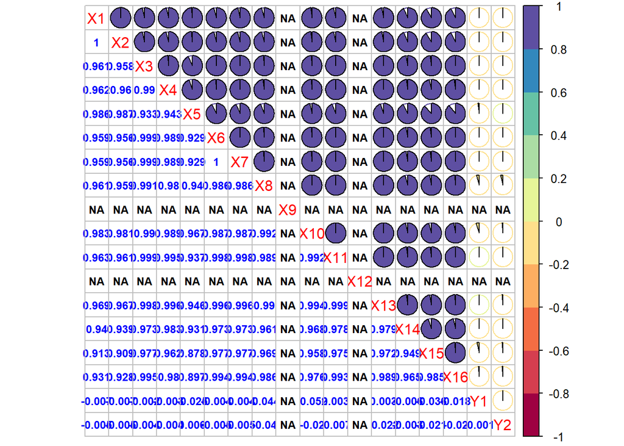

```r
corrplot.mixed(cor(navalData), upper.col = brewer.pal(n=10, name ="Spectral"),
               lower.col = "blue", upper = "pie", number.cex = .75, number.digits = 3, na.label = "NA")
```

Here, we will plot a 2-dimensional scatterplot of all pairs of variables. This can show us whether the variables will have any linearity between each other.

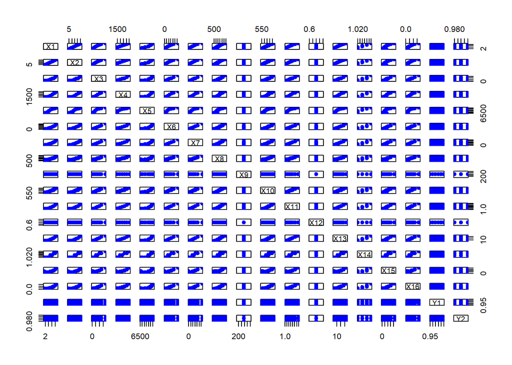

```r
pairs(navalData, pch = 19, col = "blue")
```

Removing values that are not important to our prediction. Namely, `X7` because its a duplicate, and `X9` & `X12` because they are variables that contain the same information.

```r
x <- c(1,2,3,4,5,6,8,10,11,13,14,15,16,17,18)
navalDataRevised <- navalData[,x]
cor(navalDataRevised)
```

```
##               X1           X2           X3           X4           X5
## X1   1.000000000  0.999918932  0.961060859  0.962170527  0.986018461
## X2   0.999918932  1.000000000  0.958307867  0.960416376  0.986548821
## X3   0.961060859  0.958307867  1.000000000  0.989710627  0.932836760
## X4   0.962170527  0.960416376  0.989710627  1.000000000  0.942750924
## X5   0.986018461  0.986548821  0.932836760  0.942750924  1.000000000
## X6   0.959275784  0.956445990  0.999172632  0.988613230  0.929454314
## X8   0.961363106  0.958975323  0.991117108  0.979605879  0.939689075
## X10  0.982901522  0.981293328  0.990183964  0.989218702  0.966616938
## X11  0.963095924  0.960647472  0.998888416  0.995108006  0.937287676
## X13  0.969167929  0.967014773  0.997576076  0.996031986  0.945731565
## X14  0.939948005  0.938787319  0.972969659  0.982595630  0.930584897
## X15  0.912781187  0.909186053  0.977483586  0.961994252  0.878080018
## X16  0.931333951  0.927768436  0.995035351  0.980197416  0.896626923
## Y1  -0.006831136 -0.006896537 -0.002047114 -0.003118643 -0.025153234
## Y2  -0.004758308 -0.004737331 -0.004087297 -0.004376194  0.005878501
##               X6          X8         X10          X11          X13          X14
## X1   0.959275784  0.96136311  0.98290152  0.963095924  0.969167929  0.939948005
## X2   0.956445990  0.95897532  0.98129333  0.960647472  0.967014773  0.938787319
## X3   0.999172632  0.99111711  0.99018396  0.998888416  0.997576076  0.972969659
## X4   0.988613230  0.97960588  0.98921870  0.995108006  0.996031986  0.982595630
## X5   0.929454314  0.93968908  0.96661694  0.937287676  0.945731565  0.930584897
## X6   1.000000000  0.98594120  0.98733461  0.997995101  0.996164013  0.972923822
## X8   0.985941204  1.00000000  0.99228188  0.989368313  0.990447825  0.961339751
## X10  0.987334609  0.99228188  1.00000000  0.991669537  0.994336058  0.967675185
## X11  0.997995101  0.98936831  0.99166954  1.000000000  0.999397450  0.978193788
## X13  0.996164013  0.99044783  0.99433606  0.999397450  1.000000000  0.978681796
## X14  0.972923822  0.96133975  0.96767519  0.978193788  0.978681796  1.000000000
## X15  0.977039542  0.96927553  0.95811467  0.975334806  0.971710488  0.949322120
## X16  0.994307212  0.98623588  0.97630253  0.992683665  0.989216457  0.964529281
## Y1  -0.004261568 -0.04428452 -0.05189850  0.002945739  0.003249422 -0.005631884
## Y2  -0.004578771 -0.03974577 -0.02004147 -0.006871948 -0.021517833 -0.002865694
##             X15         X16           Y1           Y2
## X1   0.91278119  0.93133395 -0.006831136 -0.004758308
## X2   0.90918605  0.92776844 -0.006896537 -0.004737331
## X3   0.97748359  0.99503535 -0.002047114 -0.004087297
## X4   0.96199425  0.98019742 -0.003118643 -0.004376194
## X5   0.87808002  0.89662692 -0.025153234  0.005878501
## X6   0.97703954  0.99430721 -0.004261568 -0.004578771
## X8   0.96927553  0.98623588 -0.044284518 -0.039745766
## X10  0.95811467  0.97630253 -0.051898504 -0.020041470
## X11  0.97533481  0.99268366  0.002945739 -0.006871948
## X13  0.97171049  0.98921646  0.003249422 -0.021517833
## X14  0.94932212  0.96452928 -0.005631884 -0.002865694
## X15  1.00000000  0.98533613 -0.035551428 -0.021399292
## X16  0.98533613  1.00000000 -0.017788588 -0.020441146
## Y1  -0.03555143 -0.01778859  1.000000000 -0.001220496
## Y2  -0.02139929 -0.02044115 -0.001220496  1.000000000
```

As seen, the warning has disappeared, and we can move on to explore other components of our dataset.

A quick summary of our dataset after removing redundant variables.

```r
summary(navalDataRevised)
```

```
##        X1              X2              X3                X4
##  Min.   :1.140   Min.   : 3.00   Min.   :  253.6   Min.   :1308
##  1st Qu.:3.140   1st Qu.: 9.00   1st Qu.: 8375.9   1st Qu.:1387
##  Median :5.140   Median :15.00   Median :21630.7   Median :1924
##  Mean   :5.162   Mean   :14.98   Mean   :27160.0   Mean   :2134
##  3rd Qu.:7.150   3rd Qu.:21.00   3rd Qu.:39001.2   3rd Qu.:2678
##  Max.   :9.300   Max.   :27.00   Max.   :72783.3   Max.   :3561
##        X5             X6               X8              X10
##  Min.   :6589   Min.   :  5.30   Min.   : 444.7   Min.   :541.0
##  1st Qu.:7058   1st Qu.: 60.32   1st Qu.: 590.0   1st Qu.:578.1
##  Median :8482   Median :175.27   Median : 706.0   Median :637.1
##  Mean   :8198   Mean   :226.51   Mean   : 734.9   Mean   :646.0
##  3rd Qu.:9132   3rd Qu.:332.36   3rd Qu.: 833.6   3rd Qu.:693.8
##  Max.   :9797   Max.   :645.25   Max.   :1115.8   Max.   :789.1
##       X11             X13             X14            X15
##  Min.   :1.090   Min.   : 5.83   Min.   :1.02   Min.   : 0.00
##  1st Qu.:1.390   1st Qu.: 7.45   1st Qu.:1.02   1st Qu.:14.12
##  Median :2.080   Median :11.09   Median :1.03   Median :25.27
##  Mean   :2.349   Mean   :12.28   Mean   :1.03   Mean   :33.56
##  3rd Qu.:2.980   3rd Qu.:15.66   3rd Qu.:1.04   3rd Qu.:44.53
##  Max.   :4.560   Max.   :23.14   Max.   :1.05   Max.   :92.56
##       X16               Y1               Y2
##  Min.   :0.0700   Min.   :0.9500   Min.   :0.9800
##  1st Qu.:0.2500   1st Qu.:0.9600   1st Qu.:0.9800
##  Median :0.5000   Median :0.9800   Median :0.9900
##  Mean   :0.6607   Mean   :0.9757   Mean   :0.9885
##  3rd Qu.:0.8800   3rd Qu.:0.9900   3rd Qu.:0.9900
##  Max.   :1.8300   Max.   :1.0000   Max.   :1.0000
```

**For the linear model, we will be using Adjusted R-Squared as a measurement for model improvement. When removing an insignificantvariable, Multiple R-squared may not increase but adjusted will.The same occurs when adding an insignificant variable. Multiple R-squared will increase, but adjusted may not. This happens as Adjusted R-Squared takes into consideration the number of variables being tested, while Multiple R-squared does not.**

### Basic Linear Modeling for Prediction of Y1

Linear model on `Y1` vs the rest of the variables. Model 1, Full Model

```r
lmFit_Y1_V1 <- lm(Y1 ~ . - Y2, data = navalDataRevised)

# Summary of Model 1
summary(lmFit_Y1_V1)
```

```
##
## Call:
## lm(formula = Y1 ~ . - Y2, data = navalDataRevised)
##
## Residuals:
##        Min         1Q     Median         3Q        Max
## -0.0199370 -0.0041844  0.0000088  0.0041979  0.0194989
##
## Coefficients:
##               Estimate Std. Error  t value Pr(>|t|)
## (Intercept)  4.802e+00  6.551e-02   73.311   <2e-16 ***
## X1           1.427e-01  5.819e-03   24.523   <2e-16 ***
## X2          -3.930e-02  1.830e-03  -21.479   <2e-16 ***
## X3          -3.308e-06  3.635e-07   -9.099   <2e-16 ***
## X4           2.062e-07  2.958e-06    0.070    0.944
## X5           4.245e-05  8.700e-07   48.799   <2e-16 ***
## X6          -5.856e-04  3.239e-05  -18.080   <2e-16 ***
## X8           2.730e-04  1.984e-05   13.760   <2e-16 ***
## X10         -4.138e-03  3.687e-05 -112.238   <2e-16 ***
## X11          2.038e-01  8.331e-03   24.459   <2e-16 ***
## X13          1.450e-02  8.543e-04   16.972   <2e-16 ***
## X14         -2.288e+00  6.100e-02  -37.505   <2e-16 ***
## X15         -6.124e-04  1.776e-05  -34.481   <2e-16 ***
## X16          1.393e-01  1.072e-02   13.002   <2e-16 ***
## ---
## Signif. codes:  0 '***' 0.001 '**' 0.01 '*' 0.05 '.' 0.1 ' ' 1
##
## Residual standard error: 0.006122 on 9986 degrees of freedom
## Multiple R-squared:  0.8398, Adjusted R-squared:  0.8396
## F-statistic:  4027 on 13 and 9986 DF,  p-value: < 2.2e-16
```

The “Full Model” statistics provides us with useful information on the residuals, coefficients and formula of the linear model. The coefficients show how significant each variable will be when predicting for `Y1`.

From here on out, we can improve the model by removing the least significant variable one at a time. Variables with a higher value of **Pr(>|t|)** will be the first to be removed.

Pr(>|t|) is the probability of the coefficient of a variable going to **zero**. The higher this probability, the less significant it is. As we can see from the table, `X4` is the least significant variable, and we will be removing it from the linear model.

Linear model on `Y1` without X4. Model 2

```r
lmFit_Y1_V2 <- update(lmFit_Y1_V1, ~ . - X4, data = navalDataRevised)

# Summary of Model 2
summary(lmFit_Y1_V2)
```

```
##
## Call:
## lm(formula = Y1 ~ X1 + X2 + X3 + X5 + X6 + X8 + X10 + X11 + X13 +
##     X14 + X15 + X16, data = navalDataRevised)
##
## Residuals:
##        Min         1Q     Median         3Q        Max
## -0.0199368 -0.0041845  0.0000096  0.0041998  0.0194988
##
## Coefficients:
##               Estimate Std. Error  t value Pr(>|t|)
## (Intercept)  4.801e+00  6.161e-02   77.923   <2e-16 ***
## X1           1.426e-01  5.685e-03   25.086   <2e-16 ***
## X2          -3.927e-02  1.800e-03  -21.821   <2e-16 ***
## X3          -3.312e-06  3.574e-07   -9.269   <2e-16 ***
## X5           4.243e-05  8.101e-07   52.380   <2e-16 ***
## X6          -5.855e-04  3.238e-05  -18.085   <2e-16 ***
## X8           2.728e-04  1.976e-05   13.811   <2e-16 ***
## X10         -4.137e-03  3.034e-05 -136.333   <2e-16 ***
## X11          2.041e-01  7.218e-03   28.270   <2e-16 ***
## X13          1.450e-02  8.510e-04   17.044   <2e-16 ***
## X14         -2.287e+00  5.957e-02  -38.391   <2e-16 ***
## X15         -6.123e-04  1.769e-05  -34.611   <2e-16 ***
## X16          1.391e-01  1.019e-02   13.657   <2e-16 ***
## ---
## Signif. codes:  0 '***' 0.001 '**' 0.01 '*' 0.05 '.' 0.1 ' ' 1
##
## Residual standard error: 0.006122 on 9987 degrees of freedom
## Multiple R-squared:  0.8398, Adjusted R-squared:  0.8396
## F-statistic:  4363 on 12 and 9987 DF,  p-value: < 2.2e-16
```

After removing `X4`, which had a high probability of 0.944, it did not improve its Adjusted R-squared. However, as removing it did not affect the probabilities of the remaining variables, it was safe to remove from the formula.

We have now removed variables that had the highest probability of going to zero. The remaining variables are all signifcant to our linear model. We will now introduce **non-linear variables and interactions** between variables to the model.

### Advanced Linear Modeling for Prediction of Y1

Linear model on `Y1`, introducing non-linear term: `X10^2`. Model 3

```r
lmFit_Y1_V3 <- update(lmFit_Y1_V2, ~ . + I(X10^2), data = navalDataRevised)

# Summary of Model 3
summary(lmFit_Y1_V3)
```

```
##
## Call:
## lm(formula = Y1 ~ X1 + X2 + X3 + X5 + X6 + X8 + X10 + X11 + X13 +
##     X14 + X15 + X16 + I(X10^2), data = navalDataRevised)
##
## Residuals:
##        Min         1Q     Median         3Q        Max
## -0.0183311 -0.0034680  0.0001834  0.0034452  0.0167750
##
## Coefficients:
##               Estimate Std. Error t value Pr(>|t|)
## (Intercept)  8.617e+00  7.166e-02  120.24   <2e-16 ***
## X1           1.601e-01  4.581e-03   34.96   <2e-16 ***
## X2          -4.354e-02  1.449e-03  -30.04   <2e-16 ***
## X3          -3.209e-06  2.876e-07  -11.16   <2e-16 ***
## X5           6.524e-05  7.215e-07   90.42   <2e-16 ***
## X6          -4.712e-04  2.610e-05  -18.05   <2e-16 ***
## X8           1.209e-03  2.034e-05   59.42   <2e-16 ***
## X10         -1.639e-02  1.679e-04  -97.59   <2e-16 ***
## X11          3.262e-01  6.040e-03   54.00   <2e-16 ***
## X13          1.533e-02  6.849e-04   22.39   <2e-16 ***
## X14         -2.624e+00  4.815e-02  -54.49   <2e-16 ***
## X15         -2.715e-04  1.497e-05  -18.14   <2e-16 ***
## X16         -4.506e-01  1.145e-02  -39.35   <2e-16 ***
## I(X10^2)     8.511e-06  1.154e-07   73.74   <2e-16 ***
## ---
## Signif. codes:  0 '***' 0.001 '**' 0.01 '*' 0.05 '.' 0.1 ' ' 1
##
## Residual standard error: 0.004926 on 9986 degrees of freedom
## Multiple R-squared:  0.8963, Adjusted R-squared:  0.8961
## F-statistic:  6638 on 13 and 9986 DF,  p-value: < 2.2e-16
```

After introducing this non-linear term, we can infer that it is indeed useful as the Adjusted R-squared increased significantly, from 0.8396 to 0.8961! Folllowing this trend, we will introduce variables that show a high correlation with Y1, namely, `X8` and `X15`.

Linear model on `Y1`, introducing non-linear term: `X8^2`. Model 4

```r
lmFit_Y1_V4 <- update(lmFit_Y1_V3, ~ . + I(X8^2), data = navalDataRevised)

# Summary of Model 4
summary(lmFit_Y1_V4)
```

```
##
## Call:
## lm(formula = Y1 ~ X1 + X2 + X3 + X5 + X6 + X8 + X10 + X11 + X13 +
##     X14 + X15 + X16 + I(X10^2) + I(X8^2), data = navalDataRevised)
##
## Residuals:
##       Min        1Q    Median        3Q       Max
## -0.015775 -0.002771  0.000032  0.002821  0.012115
##
## Coefficients:
##               Estimate Std. Error t value Pr(>|t|)
## (Intercept)  1.301e+01  8.111e-02  160.35   <2e-16 ***
## X1           2.051e-01  3.692e-03   55.54   <2e-16 ***
## X2          -5.960e-02  1.172e-03  -50.84   <2e-16 ***
## X3          -1.297e-05  2.623e-07  -49.46   <2e-16 ***
## X5           1.222e-04  9.431e-07  129.55   <2e-16 ***
## X6           5.933e-04  2.504e-05   23.70   <2e-16 ***
## X8           3.643e-03  3.585e-05  101.61   <2e-16 ***
## X10         -3.160e-02  2.404e-04 -131.42   <2e-16 ***
## X11          1.716e-01  5.217e-03   32.90   <2e-16 ***
## X13          2.919e-02  5.745e-04   50.80   <2e-16 ***
## X14         -3.148e+00  3.892e-02  -80.89   <2e-16 ***
## X15         -8.328e-04  1.401e-05  -59.45   <2e-16 ***
## X16         -1.747e-01  9.806e-03  -17.81   <2e-16 ***
## I(X10^2)     1.989e-05  1.755e-07  113.34   <2e-16 ***
## I(X8^2)     -1.796e-06  2.360e-08  -76.09   <2e-16 ***
## ---
## Signif. codes:  0 '***' 0.001 '**' 0.01 '*' 0.05 '.' 0.1 ' ' 1
##
## Residual standard error: 0.003919 on 9985 degrees of freedom
## Multiple R-squared:  0.9343, Adjusted R-squared:  0.9343
## F-statistic: 1.015e+04 on 14 and 9985 DF,  p-value: < 2.2e-16
```

From the summary table of Model 4, it is again proven that X8^2 is a useful variable. The Adjusted R-squared increased again, from 0.8961 to 0.9343. Now, we will add in X15^2.

Linear model on `Y1`, introducing non-linear term: `X15^2`. Model 5

```r
lmFit_Y1_V5 <- update(lmFit_Y1_V4, ~ . + I(X15^2), data = navalDataRevised)

# Summary of Model 5
summary(lmFit_Y1_V5)
```

```
##
## Call:
## lm(formula = Y1 ~ X1 + X2 + X3 + X5 + X6 + X8 + X10 + X11 + X13 +
##     X14 + X15 + X16 + I(X10^2) + I(X8^2) + I(X15^2), data = navalDataRevised)
##
## Residuals:
##        Min         1Q     Median         3Q        Max
## -0.0157744 -0.0027604  0.0000083  0.0028076  0.0120575
##
## Coefficients:
##               Estimate Std. Error  t value Pr(>|t|)
## (Intercept)  1.322e+01  8.720e-02  151.645  < 2e-16 ***
## X1           2.032e-01  3.695e-03   55.007  < 2e-16 ***
## X2          -5.932e-02  1.171e-03  -50.674  < 2e-16 ***
## X3          -1.411e-05  3.117e-07  -45.257  < 2e-16 ***
## X5           1.247e-04  1.013e-06  123.135  < 2e-16 ***
## X6           7.340e-04  3.265e-05   22.481  < 2e-16 ***
## X8           3.653e-03  3.580e-05  102.033  < 2e-16 ***
## X10         -3.181e-02  2.419e-04 -131.490  < 2e-16 ***
## X11          1.724e-01  5.207e-03   33.101  < 2e-16 ***
## X13          2.743e-02  6.305e-04   43.502  < 2e-16 ***
## X14         -3.285e+00  4.388e-02  -74.874  < 2e-16 ***
## X15         -7.569e-04  1.800e-05  -42.046  < 2e-16 ***
## X16         -1.327e-01  1.162e-02  -11.419  < 2e-16 ***
## I(X10^2)     1.995e-05  1.753e-07  113.786  < 2e-16 ***
## I(X8^2)     -1.789e-06  2.358e-08  -75.857  < 2e-16 ***
## I(X15^2)    -4.918e-06  7.346e-07   -6.696 2.26e-11 ***
## ---
## Signif. codes:  0 '***' 0.001 '**' 0.01 '*' 0.05 '.' 0.1 ' ' 1
##
## Residual standard error: 0.003911 on 9984 degrees of freedom
## Multiple R-squared:  0.9346, Adjusted R-squared:  0.9345
## F-statistic:  9518 on 15 and 9984 DF,  p-value: < 2.2e-16
```

From the summary table of Model 5, it shows that the Adjusted R-squared only improved by 0.0002. However, as none of the other variables increased in Pr(>|t|), and X15^2 has a very low probability, we can keep this variable in our linear regression formula.

Moving forward, I decided to introduce to the formula non-linear variables(intervals) which showed prominent trends of non-linearity. These variables are `X10`, `X8` and `X15`. We will be introducing non-linear variables `X10:X8`, `X10:X15` and `X8:X1`5.

Linear model on `Y1`, introducing non-linear term: `X10:X8`. Model 6

```r
lmFit_Y1_V6 <- update(lmFit_Y1_V5, ~ . + X10:X8, data = navalDataRevised)

# Summary of Model 6
summary(lmFit_Y1_V6)
```

```
##
## Call:
## lm(formula = Y1 ~ X1 + X2 + X3 + X5 + X6 + X8 + X10 + X11 + X13 +
##     X14 + X15 + X16 + I(X10^2) + I(X8^2) + I(X15^2) + X8:X10,
##     data = navalDataRevised)
##
## Residuals:
##        Min         1Q     Median         3Q        Max
## -0.0152737 -0.0027450  0.0000564  0.0028249  0.0114049
##
## Coefficients:
##               Estimate Std. Error t value Pr(>|t|)
## (Intercept)  1.527e+01  1.395e-01 109.410  < 2e-16 ***
## X1           2.213e-01  3.762e-03  58.844  < 2e-16 ***
## X2          -6.485e-02  1.189e-03 -54.545  < 2e-16 ***
## X3          -1.736e-05  3.531e-07 -49.167  < 2e-16 ***
## X5           1.344e-04  1.124e-06 119.554  < 2e-16 ***
## X6           1.040e-03  3.609e-05  28.815  < 2e-16 ***
## X8           7.087e-03  1.884e-04  37.625  < 2e-16 ***
## X10         -4.180e-02  5.887e-04 -70.999  < 2e-16 ***
## X11          1.520e-01  5.235e-03  29.039  < 2e-16 ***
## X13          3.083e-02  6.465e-04  47.689  < 2e-16 ***
## X14         -3.399e+00  4.358e-02 -78.007  < 2e-16 ***
## X15         -9.333e-04  2.009e-05 -46.453  < 2e-16 ***
## X16         -1.147e-01  1.147e-02 -10.000  < 2e-16 ***
## I(X10^2)     3.247e-05  6.965e-07  46.626  < 2e-16 ***
## I(X8^2)     -3.809e-07  7.933e-08  -4.802 1.59e-06 ***
## I(X15^2)    -1.563e-06  7.445e-07  -2.100   0.0358 *
## X8:X10      -8.545e-06  4.605e-07 -18.556  < 2e-16 ***
## ---
## Signif. codes:  0 '***' 0.001 '**' 0.01 '*' 0.05 '.' 0.1 ' ' 1
##
## Residual standard error: 0.003845 on 9983 degrees of freedom
## Multiple R-squared:  0.9368, Adjusted R-squared:  0.9367
## F-statistic:  9252 on 16 and 9983 DF,  p-value: < 2.2e-16
```

From the summary of Model 6, we can see that the Adjusted R-squared once again had an increase, from 0.9345 to 0.9367!

Linear model on `Y1`, introducing non-linear term: `X10:X15`. Model 7

```r
lmFit_Y1_V7 <- update(lmFit_Y1_V6, ~ . + X10:X15, data = navalDataRevised)

# Summary of Model 7
summary(lmFit_Y1_V7)
```

```
##
## Call:
## lm(formula = Y1 ~ X1 + X2 + X3 + X5 + X6 + X8 + X10 + X11 + X13 +
##     X14 + X15 + X16 + I(X10^2) + I(X8^2) + I(X15^2) + X8:X10 +
##     X10:X15, data = navalDataRevised)
##
## Residuals:
##        Min         1Q     Median         3Q        Max
## -0.0107287 -0.0027213  0.0000023  0.0027241  0.0108969
##
## Coefficients:
##               Estimate Std. Error t value Pr(>|t|)
## (Intercept)  1.478e+01  1.328e-01 111.312   <2e-16 ***
## X1           2.105e-01  3.574e-03  58.895   <2e-16 ***
## X2          -6.272e-02  1.127e-03 -55.657   <2e-16 ***
## X3          -1.958e-05  3.404e-07 -57.510   <2e-16 ***
## X5           1.443e-04  1.103e-06 130.852   <2e-16 ***
## X6           1.224e-03  3.457e-05  35.394   <2e-16 ***
## X8           7.725e-03  1.792e-04  43.101   <2e-16 ***
## X10         -3.996e-02  5.597e-04 -71.395   <2e-16 ***
## X11          1.598e-01  4.960e-03  32.216   <2e-16 ***
## X13          3.313e-02  6.155e-04  53.831   <2e-16 ***
## X14         -3.590e+00  4.162e-02 -86.269   <2e-16 ***
## X15         -1.333e-02  3.639e-04 -36.636   <2e-16 ***
## X16         -1.818e-01  1.103e-02 -16.485   <2e-16 ***
## I(X10^2)     3.056e-05  6.615e-07  46.207   <2e-16 ***
## I(X8^2)     -6.857e-07  7.560e-08  -9.069   <2e-16 ***
## I(X15^2)    -2.743e-05  1.035e-06 -26.503   <2e-16 ***
## X8:X10      -8.791e-06  4.359e-07 -20.167   <2e-16 ***
## X10:X15      2.326e-05  6.816e-07  34.118   <2e-16 ***
## ---
## Signif. codes:  0 '***' 0.001 '**' 0.01 '*' 0.05 '.' 0.1 ' ' 1
##
## Residual standard error: 0.003639 on 9982 degrees of freedom
## Multiple R-squared:  0.9434, Adjusted R-squared:  0.9433
## F-statistic:  9791 on 17 and 9982 DF,  p-value: < 2.2e-16
```

From the summary of Model 7, we can see that the Adjusted R-squared once again had an increase, from 0.9367 to 0.9433!

Linear model on `Y1`, introducing non-linear term: `X8:X15`. Model 8

```r
lmFit_Y1_V8 <- update(lmFit_Y1_V7, ~ . + X8:X15, data = navalDataRevised)

# Summary of Model 8
summary(lmFit_Y1_V8)
```

```
##
## Call:
## lm(formula = Y1 ~ X1 + X2 + X3 + X5 + X6 + X8 + X10 + X11 + X13 +
##     X14 + X15 + X16 + I(X10^2) + I(X8^2) + I(X15^2) + X8:X10 +
##     X10:X15 + X8:X15, data = navalDataRevised)
##
## Residuals:
##       Min        1Q    Median        3Q       Max
## -0.010349 -0.002706  0.000005  0.002722  0.011194
##
## Coefficients:
##               Estimate Std. Error t value Pr(>|t|)
## (Intercept)  1.485e+01  1.343e-01 110.552   <2e-16 ***
## X1           2.100e-01  3.575e-03  58.750   <2e-16 ***
## X2          -6.261e-02  1.127e-03 -55.552   <2e-16 ***
## X3          -1.958e-05  3.402e-07 -57.541   <2e-16 ***
## X5           1.441e-04  1.103e-06 130.659   <2e-16 ***
## X6           1.228e-03  3.459e-05  35.513   <2e-16 ***
## X8           7.708e-03  1.792e-04  43.004   <2e-16 ***
## X10         -4.014e-02  5.622e-04 -71.398   <2e-16 ***
## X11          1.594e-01  4.959e-03  32.153   <2e-16 ***
## X13          3.286e-02  6.214e-04  52.877   <2e-16 ***
## X14         -3.602e+00  4.177e-02 -86.247   <2e-16 ***
## X15         -1.253e-02  4.426e-04 -28.313   <2e-16 ***
## X16         -1.728e-01  1.139e-02 -15.175   <2e-16 ***
## I(X10^2)     3.067e-05  6.620e-07  46.330   <2e-16 ***
## I(X8^2)     -7.610e-07  7.920e-08  -9.608   <2e-16 ***
## I(X15^2)    -2.824e-05  1.065e-06 -26.507   <2e-16 ***
## X8:X10      -8.645e-06  4.381e-07 -19.732   <2e-16 ***
## X10:X15      2.095e-05  9.950e-07  21.060   <2e-16 ***
## X8:X15       9.159e-07  2.885e-07   3.175   0.0015 **
## ---
## Signif. codes:  0 '***' 0.001 '**' 0.01 '*' 0.05 '.' 0.1 ' ' 1
##
## Residual standard error: 0.003638 on 9981 degrees of freedom
## Multiple R-squared:  0.9435, Adjusted R-squared:  0.9434
## F-statistic:  9256 on 18 and 9981 DF,  p-value: < 2.2e-16
```

From the summary of Model 8, we can see that the Adjusted R-squared once again had an increase, from 0.9433 to 0.9434! As we can see, adding each of these variables improved the Adjusted R-squared, which also improves the linear model overall.

Now, we will proceed to remove any potential outliers in our dataset, using a formula known as **Cooks Distance**.

Plot our model to look for potential outliers

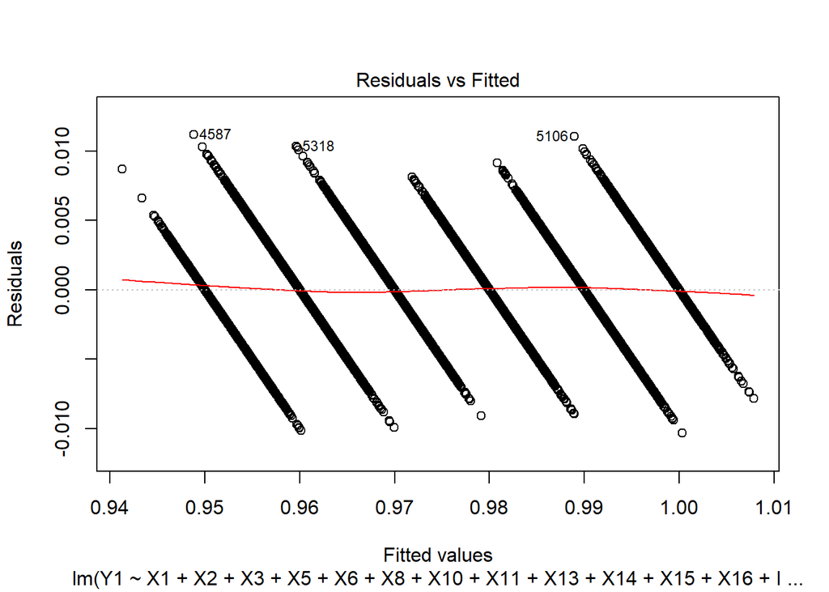

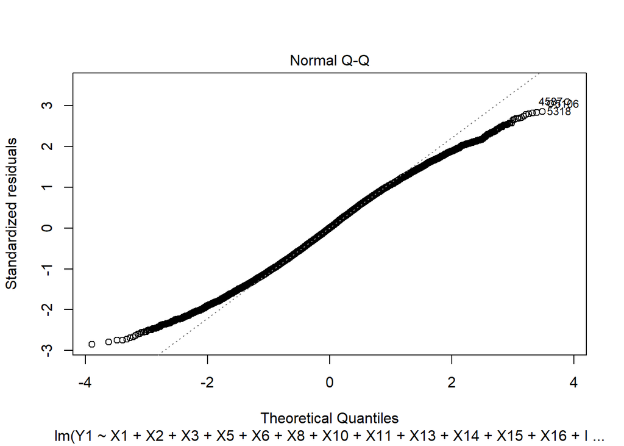

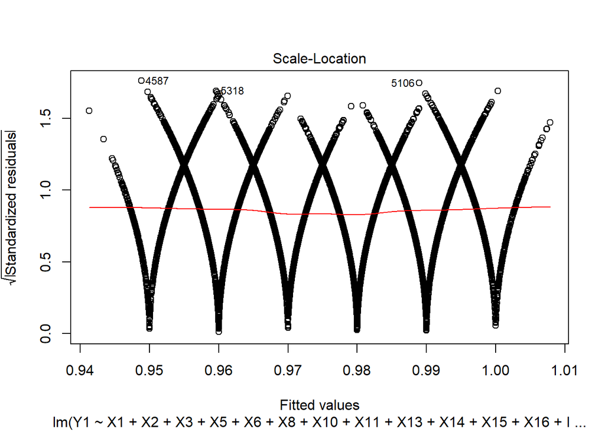

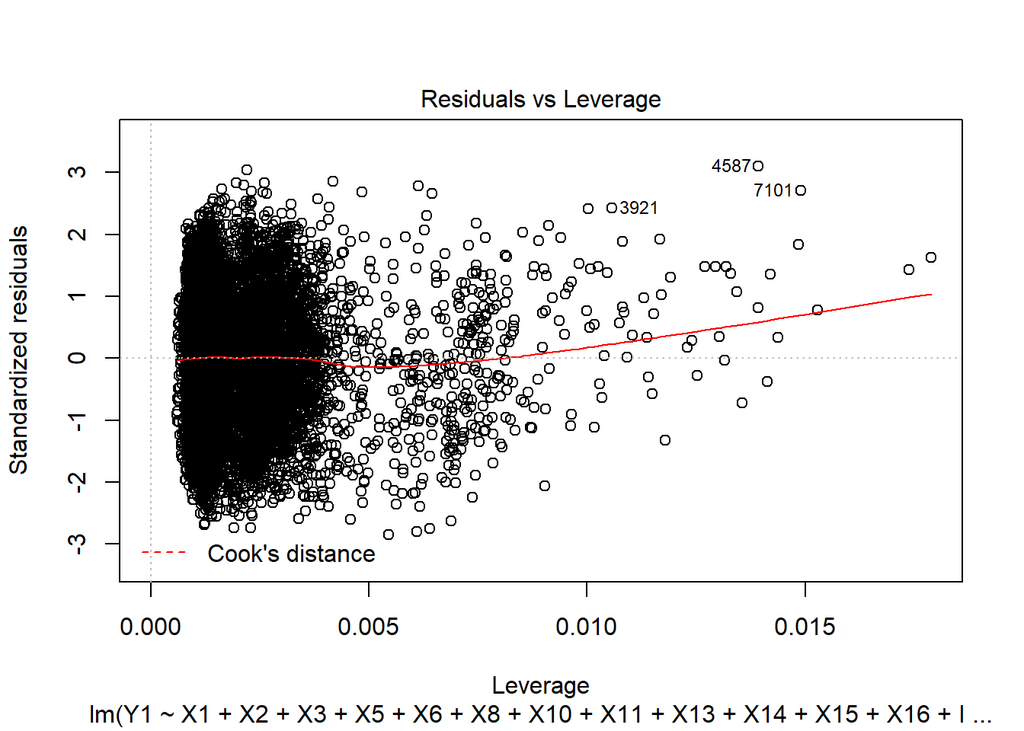

```r
plot(lmFit_Y1_V8)
```

```r
cd <- cooks.distance(lmFit_Y1_V8)
navalDataRevisedY1.clean <- navalDataRevised[abs(cd) < 4/nrow(navalDataRevised), ]
```

Viewing and confirming the variables (linear and non-linear) used in our linear model

```r
formula(lmFit_Y1_V8)
```

```
## Y1 ~ X1 + X2 + X3 + X5 + X6 + X8 + X10 + X11 + X13 + X14 + X15 +
##     X16 + I(X10^2) + I(X8^2) + I(X15^2) + X8:X10 + X10:X15 +
##     X8:X15
```

Fitting our “Best Model” with cleaned data

```r
lmFitY1 <- lm(formula(lmFit_Y1_V8), data = navalDataRevisedY1.clean)
```

Evaluation to find the increase in model performance

```r
summary(lmFitY1)
```

```
##
## Call:
## lm(formula = formula(lmFit_Y1_V8), data = navalDataRevisedY1.clean)
##
## Residuals:
##       Min        1Q    Median        3Q       Max
## -0.008928 -0.002530 -0.000010  0.002567  0.008524
##
## Coefficients:
##               Estimate Std. Error t value Pr(>|t|)
## (Intercept)  1.558e+01  1.342e-01 116.045  < 2e-16 ***
## X1           2.172e-01  3.443e-03  63.081  < 2e-16 ***
## X2          -6.502e-02  1.088e-03 -59.775  < 2e-16 ***
## X3          -2.086e-05  3.354e-07 -62.191  < 2e-16 ***
## X5           1.510e-04  1.076e-06 140.313  < 2e-16 ***
## X6           1.361e-03  3.440e-05  39.577  < 2e-16 ***
## X8           8.291e-03  1.836e-04  45.160  < 2e-16 ***
## X10         -4.265e-02  5.674e-04 -75.161  < 2e-16 ***
## X11          1.518e-01  4.688e-03  32.377  < 2e-16 ***
## X13          3.375e-02  5.923e-04  56.981  < 2e-16 ***
## X14         -3.742e+00  4.049e-02 -92.407  < 2e-16 ***
## X15         -1.259e-02  4.452e-04 -28.277  < 2e-16 ***
## X16         -1.487e-01  1.085e-02 -13.706  < 2e-16 ***
## I(X10^2)     3.308e-05  6.754e-07  48.984  < 2e-16 ***
## I(X8^2)     -7.189e-07  8.585e-08  -8.373  < 2e-16 ***
## I(X15^2)    -3.233e-05  1.157e-06 -27.932  < 2e-16 ***
## X8:X10      -9.660e-06  4.569e-07 -21.145  < 2e-16 ***
## X10:X15      2.046e-05  1.010e-06  20.253  < 2e-16 ***
## X8:X15       1.644e-06  3.241e-07   5.073 3.98e-07 ***
## ---
## Signif. codes:  0 '***' 0.001 '**' 0.01 '*' 0.05 '.' 0.1 ' ' 1
##
## Residual standard error: 0.003348 on 9465 degrees of freedom
## Multiple R-squared:  0.9518, Adjusted R-squared:  0.9517
## F-statistic: 1.038e+04 on 18 and 9465 DF,  p-value: < 2.2e-16
```

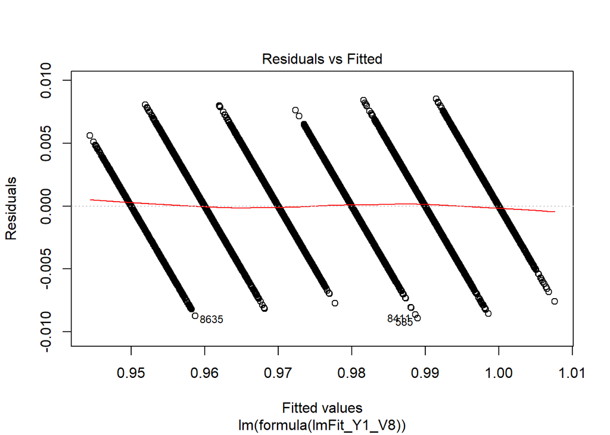

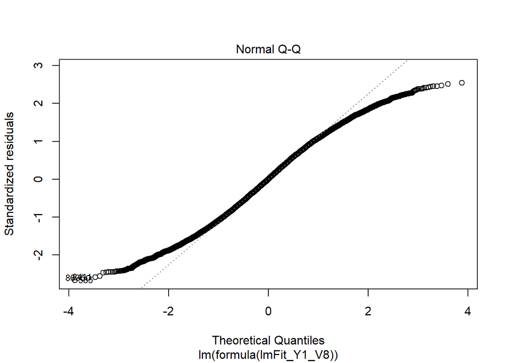

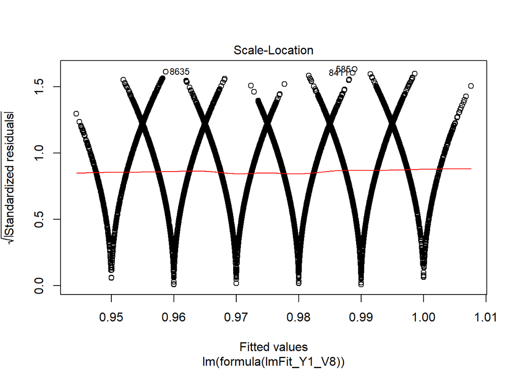

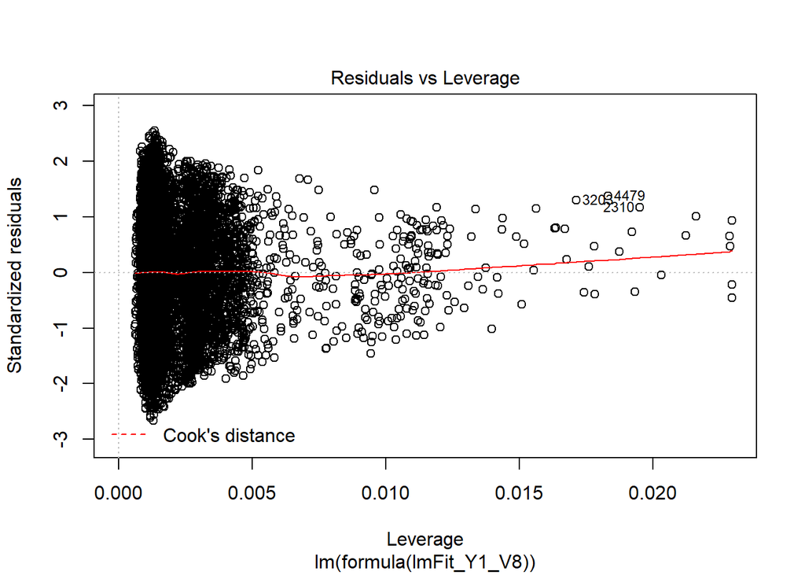

```r
plot(lmFitY1)
```

After removing the outliers, our Adjusted R-squared has once again improved, from 0.9434 to 0.9517.

**Similarly for Y2, we will be using Adjusted R-squared as a measurement of how accurate our model is.**

### Basic Linear Modeling for Prediction of Y2

Linear model on `Y2` vs the rest of the variables. Model 1, Full Model

```r
lmFit_Y2_V1 <- lm(Y2 ~ . - Y1, data = navalDataRevised)

# Summary of Model 1
summary(lmFit_Y2_V1)
```

```
##
## Call:
## lm(formula = Y2 ~ . - Y1, data = navalDataRevised)
##
## Residuals:
##        Min         1Q     Median         3Q        Max
## -0.0114915 -0.0026195  0.0000338  0.0025740  0.0129962
##
## Coefficients:
##               Estimate Std. Error  t value Pr(>|t|)
## (Intercept)  4.296e-01  3.798e-02   11.310  < 2e-16 ***
## X1           2.262e-02  3.374e-03    6.702 2.16e-11 ***
## X2          -2.146e-03  1.061e-03   -2.023   0.0431 *
## X3           1.362e-05  2.108e-07   64.616  < 2e-16 ***
## X4           4.760e-05  1.715e-06   27.754  < 2e-16 ***
## X5           2.063e-05  5.045e-07   40.890  < 2e-16 ***
## X6          -1.487e-03  1.878e-05  -79.172  < 2e-16 ***
## X8          -6.396e-04  1.150e-05  -55.602  < 2e-16 ***
## X10          3.572e-04  2.138e-05   16.706  < 2e-16 ***
## X11          1.045e-01  4.831e-03   21.630  < 2e-16 ***
## X13         -5.088e-02  4.954e-04 -102.703  < 2e-16 ***
## X14          5.964e-01  3.537e-02   16.863  < 2e-16 ***
## X15         -1.528e-04  1.030e-05  -14.841  < 2e-16 ***
## X16          2.722e-01  6.214e-03   43.806  < 2e-16 ***
## ---
## Signif. codes:  0 '***' 0.001 '**' 0.01 '*' 0.05 '.' 0.1 ' ' 1
##
## Residual standard error: 0.00355 on 9986 degrees of freedom
## Multiple R-squared:  0.7885, Adjusted R-squared:  0.7882
## F-statistic:  2864 on 13 and 9986 DF,  p-value: < 2.2e-16
```

The “Full Model” statistics provides us with useful information on the residuals, coefficients and formula of the linear model. The coefficients show how significant each variable will be when predicting for `Y2`

From here on out, we can improve the model by removing the least significant variable one at a time. Variables with a higher value of **Pr(>|t|)** will be the first to be removed.

Pr(>|t|) is the probability of the coefficient of a variable going to **zero**. The higher this probability, the less significant it is. From the table, it shows that X2 is the least significant variable, and we will be removing that from the linear model.

Linear model on ``Y2` without `X2`. Model 2

```r
lmFit_Y2_V2 <- update(lmFit_Y2_V1, ~ . - X2, data = navalDataRevised)

# Summary of Model 2
summary(lmFit_Y2_V2)
```

```
##
## Call:
## lm(formula = Y2 ~ X1 + X3 + X4 + X5 + X6 + X8 + X10 + X11 + X13 +
##     X14 + X15 + X16, data = navalDataRevised)
##
## Residuals:
##        Min         1Q     Median         3Q        Max
## -0.0114156 -0.0026292  0.0000333  0.0025772  0.0130349
##
## Coefficients:
##               Estimate Std. Error t value Pr(>|t|)
## (Intercept)  4.719e-01  3.171e-02   14.88   <2e-16 ***
## X1           1.581e-02  2.817e-04   56.13   <2e-16 ***
## X3           1.366e-05  2.097e-07   65.15   <2e-16 ***
## X4           4.698e-05  1.687e-06   27.84   <2e-16 ***
## X5           2.082e-05  4.951e-07   42.06   <2e-16 ***
## X6          -1.481e-03  1.859e-05  -79.70   <2e-16 ***
## X8          -6.403e-04  1.150e-05  -55.69   <2e-16 ***
## X10          3.640e-04  2.111e-05   17.24   <2e-16 ***
## X11          1.041e-01  4.827e-03   21.56   <2e-16 ***
## X13         -5.072e-02  4.896e-04 -103.61   <2e-16 ***
## X14          5.519e-01  2.772e-02   19.91   <2e-16 ***
## X15         -1.493e-04  1.015e-05  -14.71   <2e-16 ***
## X16          2.704e-01  6.151e-03   43.96   <2e-16 ***
## ---
## Signif. codes:  0 '***' 0.001 '**' 0.01 '*' 0.05 '.' 0.1 ' ' 1
##
## Residual standard error: 0.003551 on 9987 degrees of freedom
## Multiple R-squared:  0.7884, Adjusted R-squared:  0.7881
## F-statistic:  3101 on 12 and 9987 DF,  p-value: < 2.2e-16
```

From the table, it seems that removing X2 decreased the Adjusted R-squared value. However, it also changed the Pr(>|t|) value of X1 to be significantly lower. Thus, removing `X2` is a good thing as all variables in the formula now are very important.

We have now removed variables that had the highest probability of going to zero, and we can proceed to introduce Non-linear variables and interactions between variables to the model.

### Advanced Linear Modeling on Predicting Y2

Linear model on `Y2`, introducing non-linear term `X8^2`. Model 3

```r
lmFit_Y2_V3 <- update(lmFit_Y2_V2, ~ . + I(X8^2), data = navalDataRevised)

# Summary of Model 3
summary(lmFit_Y2_V3)
```

```
##
## Call:
## lm(formula = Y2 ~ X1 + X3 + X4 + X5 + X6 + X8 + X10 + X11 + X13 +
##     X14 + X15 + X16 + I(X8^2), data = navalDataRevised)
##
## Residuals:
##        Min         1Q     Median         3Q        Max
## -0.0115588 -0.0026356  0.0000323  0.0025706  0.0132624
##
## Coefficients:
##               Estimate Std. Error  t value Pr(>|t|)
## (Intercept)  4.541e-01  3.197e-02   14.205  < 2e-16 ***
## X1           1.591e-02  2.824e-04   56.328  < 2e-16 ***
## X3           1.386e-05  2.146e-07   64.573  < 2e-16 ***
## X4           4.385e-05  1.846e-06   23.763  < 2e-16 ***
## X5           1.966e-05  5.683e-07   34.596  < 2e-16 ***
## X6          -1.508e-03  1.964e-05  -76.780  < 2e-16 ***
## X8          -6.756e-04  1.427e-05  -47.334  < 2e-16 ***
## X10          3.524e-04  2.128e-05   16.559  < 2e-16 ***
## X11          1.179e-01  5.850e-03   20.146  < 2e-16 ***
## X13         -5.105e-02  4.953e-04 -103.058  < 2e-16 ***
## X14          5.824e-01  2.865e-02   20.333  < 2e-16 ***
## X15         -1.198e-04  1.236e-05   -9.692  < 2e-16 ***
## X16          2.371e-01  1.009e-02   23.501  < 2e-16 ***
## I(X8^2)      5.085e-08  1.221e-08    4.163 3.16e-05 ***
## ---
## Signif. codes:  0 '***' 0.001 '**' 0.01 '*' 0.05 '.' 0.1 ' ' 1
##
## Residual standard error: 0.003548 on 9986 degrees of freedom
## Multiple R-squared:  0.7888, Adjusted R-squared:  0.7885
## F-statistic:  2868 on 13 and 9986 DF,  p-value: < 2.2e-16
```

After introducing `X8^2` into the system, it seems that this variable is not very significant as it raised the Adjusted R-squared only by a slight amount. We will continue to add other variables which show strong correlations with Y2

Linear model on `Y2`, introducing non-linear term `X15^2`. Model 4

```r
lmFit_Y2_V4 <- update(lmFit_Y2_V3, ~ . + I(X15^2), data = navalDataRevised)

# Summary of Model 4
summary(lmFit_Y2_V4)
```

```
##
## Call:
## lm(formula = Y2 ~ X1 + X3 + X4 + X5 + X6 + X8 + X10 + X11 + X13 +
##     X14 + X15 + X16 + I(X8^2) + I(X15^2), data = navalDataRevised)
##
## Residuals:
##        Min         1Q     Median         3Q        Max
## -0.0121155 -0.0025077  0.0000873  0.0025317  0.0119243
##
## Coefficients:
##               Estimate Std. Error t value Pr(>|t|)
## (Intercept) -3.357e-02  3.580e-02  -0.938    0.348
## X1           2.127e-02  3.377e-04  62.976  < 2e-16 ***
## X3           1.867e-05  2.738e-07  68.197  < 2e-16 ***
## X4           7.195e-05  2.066e-06  34.833  < 2e-16 ***
## X5           1.533e-05  5.719e-07  26.796  < 2e-16 ***
## X6          -2.020e-03  2.686e-05 -75.198  < 2e-16 ***
## X8          -6.070e-04  1.402e-05 -43.309  < 2e-16 ***
## X10          6.994e-04  2.426e-05  28.827  < 2e-16 ***
## X11          5.757e-02  6.078e-03   9.473  < 2e-16 ***
## X13         -4.351e-02  5.543e-04 -78.504  < 2e-16 ***
## X14          8.863e-01  2.988e-02  29.663  < 2e-16 ***
## X15         -4.845e-04  1.806e-05 -26.825  < 2e-16 ***
## X16          1.391e-01  1.040e-02  13.379  < 2e-16 ***
## I(X8^2)     -8.319e-08  1.280e-08  -6.497 8.58e-11 ***
## I(X15^2)     2.002e-05  7.439e-07  26.905  < 2e-16 ***
## ---
## Signif. codes:  0 '***' 0.001 '**' 0.01 '*' 0.05 '.' 0.1 ' ' 1
##
## Residual standard error: 0.003426 on 9985 degrees of freedom
## Multiple R-squared:  0.803,  Adjusted R-squared:  0.8028
## F-statistic:  2908 on 14 and 9985 DF,  p-value: < 2.2e-16
```

After adding the term `X15^2`, the Adjusted R-sqaured increased quite significantly, from 0.7885 to 0.8028! This shows that adding non-linear terms that have a higher coefficient of correlation would benefit the linear regression model.

Linear model on `Y2`, introducing non-linear term `X13^2`. Model 5

```r
lmFit_Y2_V5 <- update(lmFit_Y2_V4, ~ . + I(X13^2), data = navalDataRevised)

# Summary of Model 5
summary(lmFit_Y2_V5)
```

```
##
## Call:
## lm(formula = Y2 ~ X1 + X3 + X4 + X5 + X6 + X8 + X10 + X11 + X13 +
##     X14 + X15 + X16 + I(X8^2) + I(X15^2) + I(X13^2), data = navalDataRevised)
##
## Residuals:
##        Min         1Q     Median         3Q        Max
## -0.0121502 -0.0024296  0.0001615  0.0024857  0.0130182
##
## Coefficients:
##               Estimate Std. Error t value Pr(>|t|)
## (Intercept)  2.273e-01  3.599e-02   6.315 2.81e-10 ***
## X1           2.553e-02  3.642e-04  70.107  < 2e-16 ***
## X3           1.923e-05  2.655e-07  72.438  < 2e-16 ***
## X4           1.157e-04  2.593e-06  44.608  < 2e-16 ***
## X5           3.015e-05  7.875e-07  38.281  < 2e-16 ***
## X6          -2.057e-03  2.600e-05 -79.118  < 2e-16 ***
## X8          -4.436e-04  1.490e-05 -29.780  < 2e-16 ***
## X10          3.377e-04  2.716e-05  12.434  < 2e-16 ***
## X11          5.614e-02  5.876e-03   9.555  < 2e-16 ***
## X13         -6.794e-02  1.068e-03 -63.602  < 2e-16 ***
## X14          7.021e-01  2.972e-02  23.626  < 2e-16 ***
## X15         -2.100e-04  2.032e-05 -10.334  < 2e-16 ***
## X16          4.719e-02  1.064e-02   4.436 9.27e-06 ***
## I(X8^2)     -1.059e-08  1.268e-08  -0.835    0.404
## I(X15^2)     1.077e-05  7.997e-07  13.471  < 2e-16 ***
## I(X13^2)     7.190e-04  2.720e-05  26.432  < 2e-16 ***
## ---
## Signif. codes:  0 '***' 0.001 '**' 0.01 '*' 0.05 '.' 0.1 ' ' 1
##
## Residual standard error: 0.003312 on 9984 degrees of freedom
## Multiple R-squared:  0.8159, Adjusted R-squared:  0.8156
## F-statistic:  2950 on 15 and 9984 DF,  p-value: < 2.2e-16
```

From the table, it shows that the Adjusted R-squared increased once again. However, the Pr(>|t|) value of `X8^2` has increased significantly. As this will not benefit our model, we will remove this term, while adding in `X16^2`

Linear model on Y2, introducing non-linear term `X16^2`, removing `X8^2`. Model 6

```r
lmFit_Y2_V6 <- update(lmFit_Y2_V5, ~ . + I(X16^2) - I(X8^2), data = navalDataRevised)

# Summary of Model 6
summary(lmFit_Y2_V6)
```

```
##
## Call:
## lm(formula = Y2 ~ X1 + X3 + X4 + X5 + X6 + X8 + X10 + X11 + X13 +
##     X14 + X15 + X16 + I(X15^2) + I(X13^2) + I(X16^2), data = navalDataRevised)
##
## Residuals:
##        Min         1Q     Median         3Q        Max
## -0.0113756 -0.0023657  0.0001781  0.0025042  0.0114788
##
## Coefficients:
##               Estimate Std. Error t value Pr(>|t|)
## (Intercept)  5.201e-01  3.808e-02  13.659  < 2e-16 ***
## X1           2.540e-02  3.572e-04  71.112  < 2e-16 ***
## X3           1.747e-05  2.754e-07  63.410  < 2e-16 ***
## X4           1.130e-04  2.467e-06  45.817  < 2e-16 ***
## X5           3.865e-05  8.913e-07  43.364  < 2e-16 ***
## X6          -1.846e-03  2.778e-05 -66.434  < 2e-16 ***
## X8          -4.769e-04  1.314e-05 -36.289  < 2e-16 ***
## X10          1.457e-04  2.657e-05   5.485 4.24e-08 ***
## X11          4.225e-02  4.652e-03   9.082  < 2e-16 ***
## X13         -7.459e-02  1.039e-03 -71.796  < 2e-16 ***
## X14          5.160e-01  3.076e-02  16.776  < 2e-16 ***
## X15         -6.031e-04  2.600e-05 -23.198  < 2e-16 ***
## X16          2.026e-01  1.196e-02  16.937  < 2e-16 ***
## I(X15^2)     1.985e-05  8.595e-07  23.099  < 2e-16 ***
## I(X13^2)     8.629e-04  2.707e-05  31.873  < 2e-16 ***
## I(X16^2)    -5.667e-02  2.958e-03 -19.161  < 2e-16 ***
## ---
## Signif. codes:  0 '***' 0.001 '**' 0.01 '*' 0.05 '.' 0.1 ' ' 1
##
## Residual standard error: 0.003253 on 9984 degrees of freedom
## Multiple R-squared:  0.8224, Adjusted R-squared:  0.8222
## F-statistic:  3083 on 15 and 9984 DF,  p-value: < 2.2e-16
```

From the table, the Adjusted R-squared value has increased again from 0.8156 to 0.8222.

Moving forward, I decided to introduce to the formula non-linear variables(intervals) which showed prominent trends of non-linearity. These variables are `X8`, `X15`, `X13` and `X16`. We will be introducing non-linear variables `X8:X15`, `X8:X13`, `X8:X16`, `X15:X13`, `X15:X16` and `X13:X16`.

Linear model on `Y2`, introducing non-linear terms with prominent trends. Model 7

```r
lmFit_Y2_V7 <- update(lmFit_Y2_V6, ~ . + X8:X15
                                       + X8:X13
                                       + X8:X16
                                       + X15:X13
                                       + X15:X16
                                       + X13:X16, data = navalDataRevised)

#Summary of Model 7
summary(lmFit_Y2_V7)
```

```
##
## Call:
## lm(formula = Y2 ~ X1 + X3 + X4 + X5 + X6 + X8 + X10 + X11 + X13 +
##     X14 + X15 + X16 + I(X15^2) + I(X13^2) + I(X16^2) + X8:X15 +
##     X8:X13 + X8:X16 + X13:X15 + X15:X16 + X13:X16, data = navalDataRevised)
##
## Residuals:
##        Min         1Q     Median         3Q        Max
## -0.0095369 -0.0023084  0.0002418  0.0024195  0.0080077
##
## Coefficients:
##               Estimate Std. Error t value Pr(>|t|)
## (Intercept)  6.131e-01  4.582e-02  13.382  < 2e-16 ***
## X1           2.687e-02  3.654e-04  73.543  < 2e-16 ***
## X3           2.038e-05  3.465e-07  58.822  < 2e-16 ***
## X4           8.255e-05  3.385e-06  24.386  < 2e-16 ***
## X5           3.663e-05  1.140e-06  32.125  < 2e-16 ***
## X6          -2.155e-03  3.718e-05 -57.970  < 2e-16 ***
## X8          -9.969e-04  4.275e-05 -23.321  < 2e-16 ***
## X10          2.167e-04  5.525e-05   3.922 8.83e-05 ***
## X11          1.585e-01  6.728e-03  23.552  < 2e-16 ***
## X13         -1.797e-01  4.603e-03 -39.026  < 2e-16 ***
## X14          7.560e-01  3.547e-02  21.313  < 2e-16 ***
## X15          1.389e-02  6.851e-04  20.281  < 2e-16 ***
## X16          1.428e-01  6.536e-02   2.184  0.02898 *
## I(X15^2)    -1.062e-05  1.558e-06  -6.818 9.78e-12 ***
## I(X13^2)     3.016e-03  1.783e-04  16.915  < 2e-16 ***
## I(X16^2)    -4.405e-01  5.978e-02  -7.368 1.87e-13 ***
## X8:X15      -1.060e-05  1.019e-06 -10.400  < 2e-16 ***
## X8:X13       1.291e-04  6.139e-06  21.026  < 2e-16 ***
## X8:X16      -5.126e-04  8.020e-05  -6.391 1.72e-10 ***
## X13:X15     -1.754e-03  6.261e-05 -28.020  < 2e-16 ***
## X15:X16      1.942e-02  1.146e-03  16.957  < 2e-16 ***
## X13:X16      1.486e-02  5.565e-03   2.669  0.00761 **
## ---
## Signif. codes:  0 '***' 0.001 '**' 0.01 '*' 0.05 '.' 0.1 ' ' 1
##
## Residual standard error: 0.003011 on 9978 degrees of freedom
## Multiple R-squared:  0.8479, Adjusted R-squared:  0.8476
## F-statistic:  2650 on 21 and 9978 DF,  p-value: < 2.2e-16
```

As we can see, adding these terms resulted in yet another increase in Adjusted R-squared, from 0.8222 to 0.8476. However, the terms `X16` and `X13:X16` have increased in their Pr(|t|). However since they are still rated relatively high, we can leave the model as it is.

We will now proceed to remove any potential outliers in the dataset using **Cooks Distance**.

Plot out our model to visualise and eyeball any potential outliers

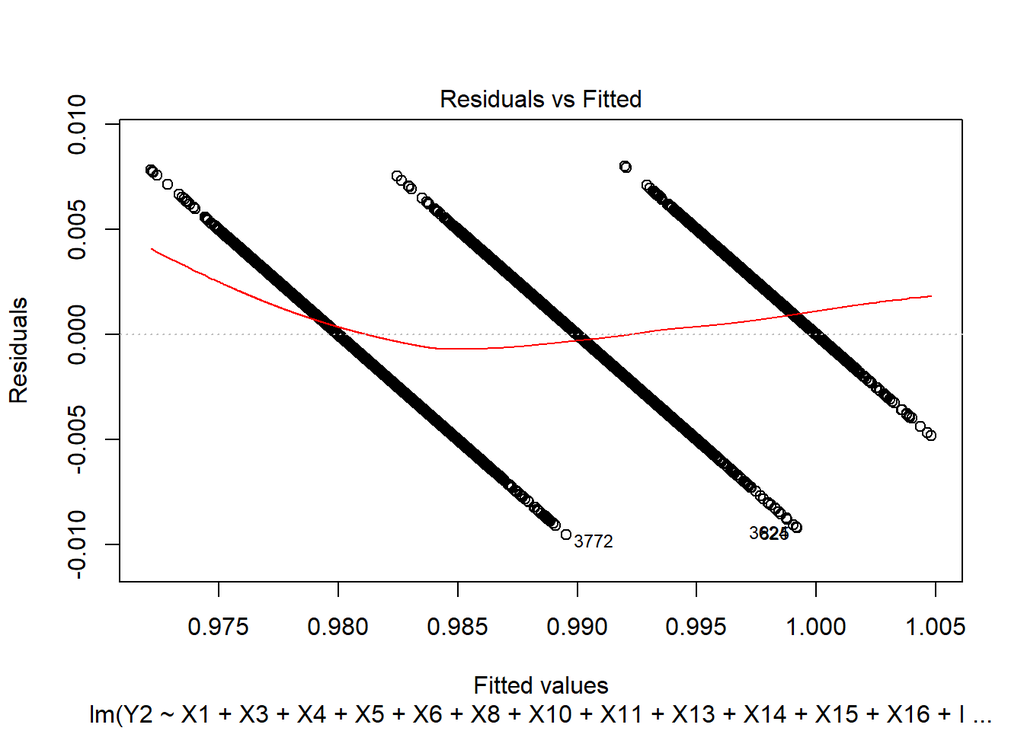

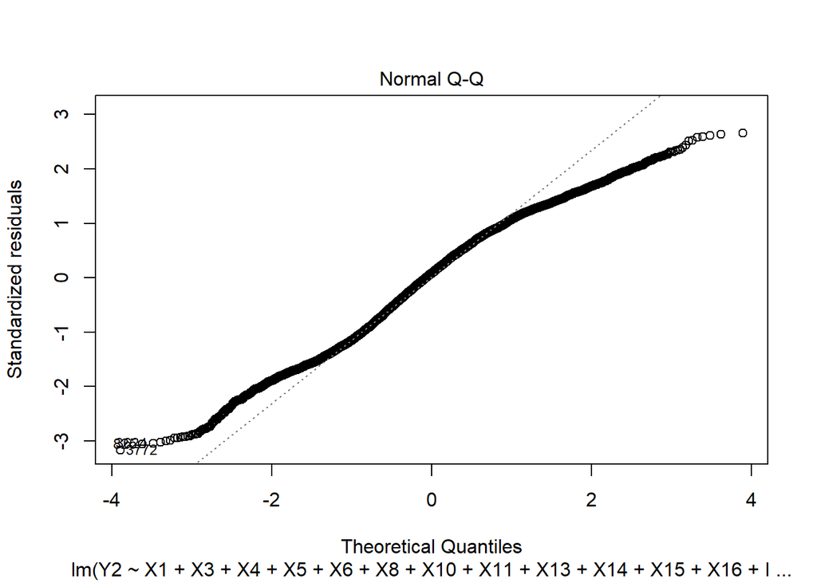

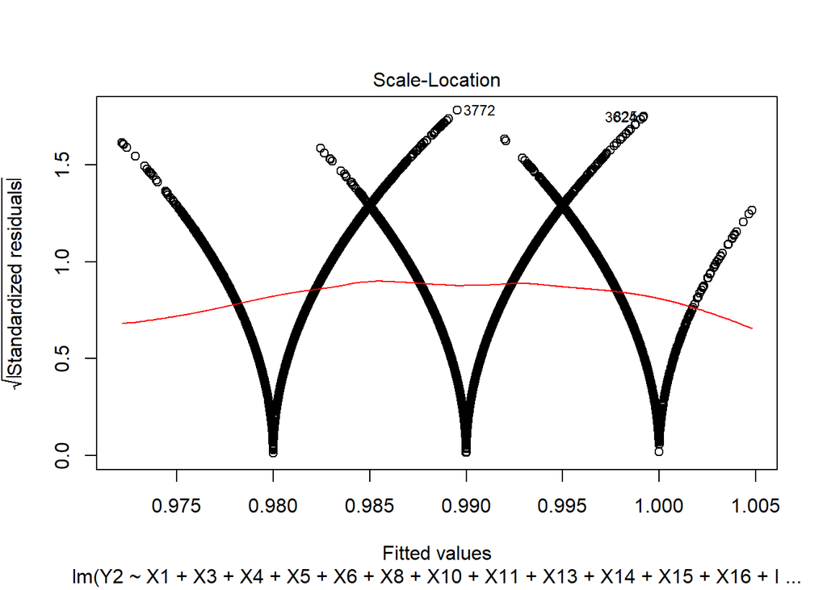

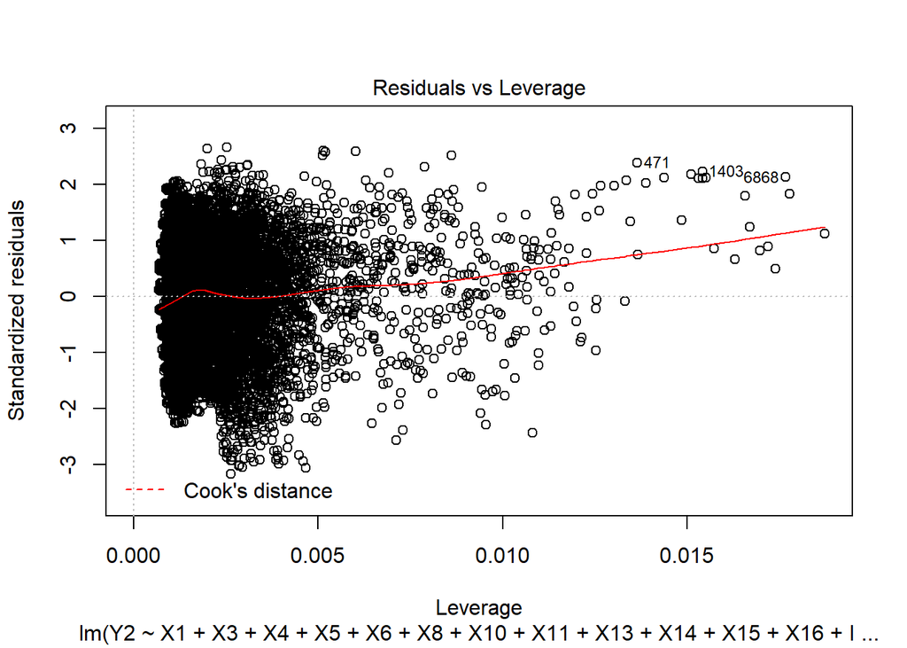

```r
plot(lmFit_Y2_V7)
```

```r
cd <- cooks.distance(lmFit_Y2_V7)
navalDataRevisedY2.clean <- navalDataRevised[abs(cd) < 4/nrow(navalDataRevised), ]
```

Viewing and confirming the variables used in our linear model

```r
formula(lmFit_Y2_V7)
```

```
## Y2 ~ X1 + X3 + X4 + X5 + X6 + X8 + X10 + X11 + X13 + X14 + X15 +
##     X16 + I(X15^2) + I(X13^2) + I(X16^2) + X8:X15 + X8:X13 +
##     X8:X16 + X13:X15 + X15:X16 + X13:X16
```

Fitting our “Best Model” with cleaned data

```r
lmFitY2 <- lm(formula(lmFit_Y2_V7), data = navalDataRevisedY2.clean)
```

Evaluation to find the increase in model performance

```r
summary(lmFitY2)
```

```
##
## Call:
## lm(formula = formula(lmFit_Y2_V7), data = navalDataRevisedY2.clean)
##
## Residuals:
##        Min         1Q     Median         3Q        Max
## -0.0063845 -0.0022362  0.0002085  0.0023095  0.0056895
##
## Coefficients:
##               Estimate Std. Error t value Pr(>|t|)
## (Intercept)  5.080e-01  4.414e-02  11.510  < 2e-16 ***
## X1           2.933e-02  3.587e-04  81.792  < 2e-16 ***
## X3           2.226e-05  3.424e-07  65.006  < 2e-16 ***
## X4           8.681e-05  3.275e-06  26.506  < 2e-16 ***
## X5           3.446e-05  1.128e-06  30.537  < 2e-16 ***
## X6          -2.393e-03  3.702e-05 -64.629  < 2e-16 ***
## X8          -1.243e-03  4.469e-05 -27.821  < 2e-16 ***
## X10          4.195e-04  5.578e-05   7.519 6.00e-14 ***
## X11          1.346e-01  6.512e-03  20.672  < 2e-16 ***
## X13         -1.951e-01  4.551e-03 -42.869  < 2e-16 ***
## X14          8.928e-01  3.453e-02  25.855  < 2e-16 ***
## X15          1.672e-02  7.039e-04  23.756  < 2e-16 ***
## X16          2.772e-01  6.556e-02   4.229 2.37e-05 ***
## I(X15^2)    -1.718e-05  1.630e-06 -10.540  < 2e-16 ***
## I(X13^2)     3.333e-03  1.727e-04  19.293  < 2e-16 ***
## I(X16^2)    -5.362e-01  5.967e-02  -8.987  < 2e-16 ***
## X8:X15      -1.519e-05  1.035e-06 -14.677  < 2e-16 ***
## X8:X13       1.582e-04  6.315e-06  25.048  < 2e-16 ***
## X8:X16      -6.327e-04  8.085e-05  -7.826 5.59e-15 ***
## X13:X15     -1.941e-03  6.454e-05 -30.071  < 2e-16 ***
## X15:X16      2.487e-02  1.176e-03  21.151  < 2e-16 ***
## X13:X16      7.398e-03  5.485e-03   1.349    0.177
## ---
## Signif. codes:  0 '***' 0.001 '**' 0.01 '*' 0.05 '.' 0.1 ' ' 1
##
## Residual standard error: 0.00278 on 9521 degrees of freedom
## Multiple R-squared:  0.8703, Adjusted R-squared:   0.87
## F-statistic:  3041 on 21 and 9521 DF,  p-value: < 2.2e-16
```

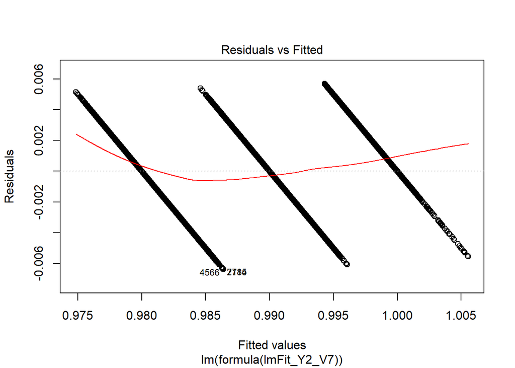

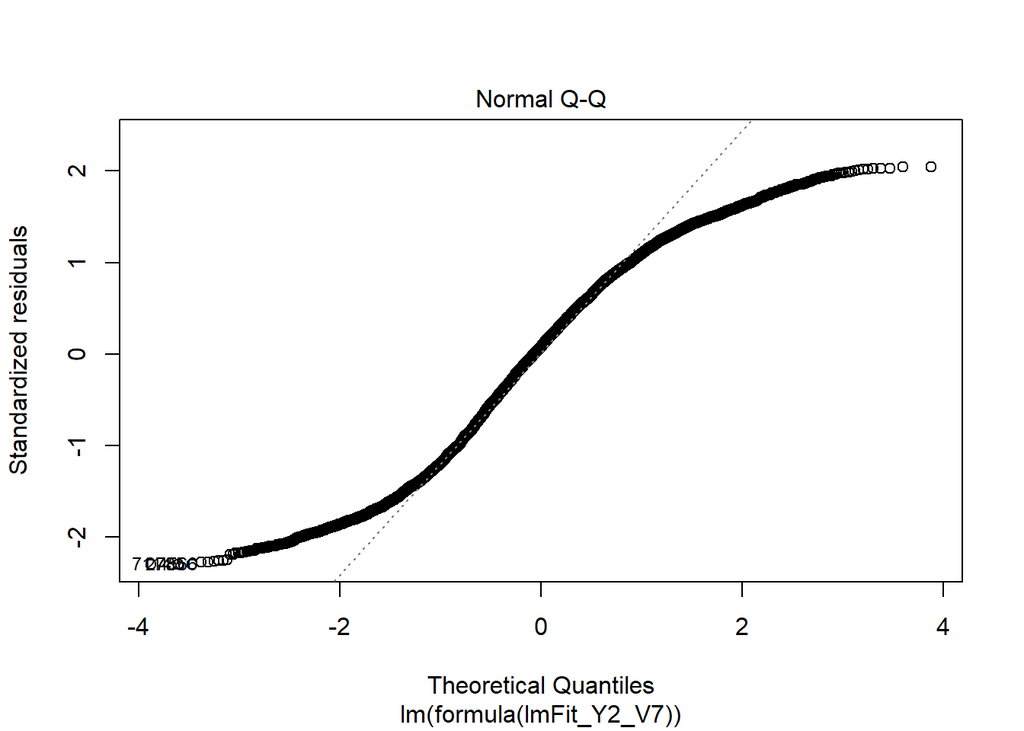

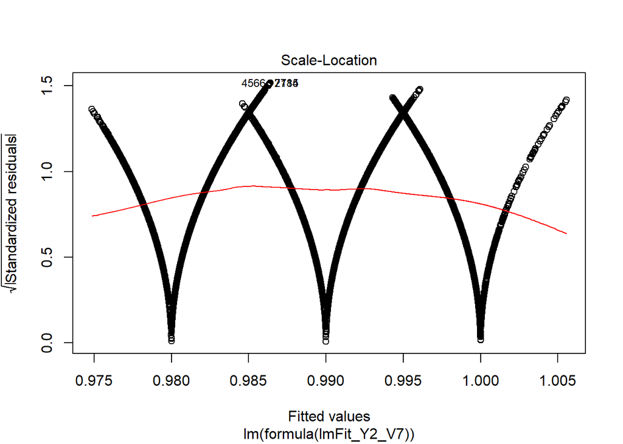

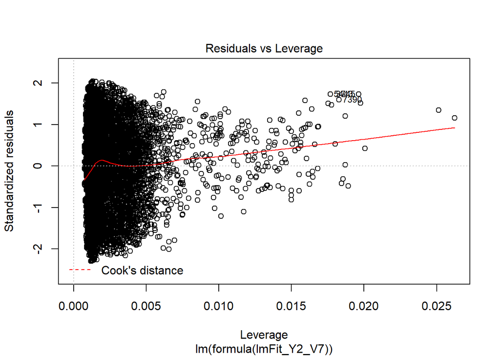

```r
plot(lmFitY2)
```

Linear model on `Y2`, introducing non-linear terms without `X13:X16`. Model 8

```r
lmFit_Y2_V8 <- update(lmFit_Y2_V7, ~ . - X13:X16, data = navalDataRevised)

#Summary of Model 8
summary(lmFit_Y2_V8)
```

```
##
## Call:
## lm(formula = Y2 ~ X1 + X3 + X4 + X5 + X6 + X8 + X10 + X11 + X13 +
##     X14 + X15 + X16 + I(X15^2) + I(X13^2) + I(X16^2) + X8:X15 +
##     X8:X13 + X8:X16 + X13:X15 + X15:X16, data = navalDataRevised)
##
## Residuals:
##        Min         1Q     Median         3Q        Max
## -0.0093853 -0.0023133  0.0002567  0.0024058  0.0079984
##
## Coefficients:
##               Estimate Std. Error t value Pr(>|t|)
## (Intercept)  6.161e-01  4.582e-02  13.445  < 2e-16 ***
## X1           2.663e-02  3.540e-04  75.211  < 2e-16 ***
## X3           2.045e-05  3.457e-07  59.162  < 2e-16 ***
## X4           7.657e-05  2.539e-06  30.156  < 2e-16 ***
## X5           3.566e-05  1.080e-06  33.004  < 2e-16 ***
## X6          -2.171e-03  3.674e-05 -59.089  < 2e-16 ***
## X8          -1.080e-03  2.936e-05 -36.784  < 2e-16 ***
## X10          2.928e-04  4.733e-05   6.187 6.36e-10 ***
## X11          1.600e-01  6.704e-03  23.872  < 2e-16 ***
## X13         -1.884e-01  3.225e-03 -58.431  < 2e-16 ***
## X14          7.716e-01  3.500e-02  22.043  < 2e-16 ***
## X15          1.323e-02  6.386e-04  20.717  < 2e-16 ***
## X16          3.039e-01  2.505e-02  12.135  < 2e-16 ***
## I(X15^2)    -9.736e-06  1.523e-06  -6.394 1.69e-10 ***
## I(X13^2)     3.385e-03  1.122e-04  30.177  < 2e-16 ***
## I(X16^2)    -3.171e-01  3.791e-02  -8.364  < 2e-16 ***
## X8:X15      -9.974e-06  9.922e-07 -10.053  < 2e-16 ***
## X8:X13       1.397e-04  4.673e-06  29.899  < 2e-16 ***
## X8:X16      -6.629e-04  5.713e-05 -11.604  < 2e-16 ***
## X13:X15     -1.685e-03  5.699e-05 -29.567  < 2e-16 ***
## X15:X16      1.850e-02  1.092e-03  16.940  < 2e-16 ***
## ---
## Signif. codes:  0 '***' 0.001 '**' 0.01 '*' 0.05 '.' 0.1 ' ' 1
##
## Residual standard error: 0.003012 on 9979 degrees of freedom
## Multiple R-squared:  0.8478, Adjusted R-squared:  0.8475
## F-statistic:  2780 on 20 and 9979 DF,  p-value: < 2.2e-16
```

From the graph, we can see that all the variables are significant, and the Adjusted R-squared only dropped by 0.0001.

We will now move on to remove potential outliers using Cooks Distance.

```r
cd <- cooks.distance(lmFit_Y2_V8)
navalDataRevisedY2.clean <- navalDataRevised[abs(cd) < 4/nrow(navalDataRevised), ]
```

Viewing and confirming variables used in our linear model

```r
formula(lmFit_Y2_V8)
```

```
## Y2 ~ X1 + X3 + X4 + X5 + X6 + X8 + X10 + X11 + X13 + X14 + X15 +
##     X16 + I(X15^2) + I(X13^2) + I(X16^2) + X8:X15 + X8:X13 +
##     X8:X16 + X13:X15 + X15:X16
```

Fitting our “Best Model” with cleaned data

```r
lmFitY2 <- lm(formula(lmFit_Y2_V8), data = navalDataRevisedY2.clean)
```

Evaluation to find the increase in model performance

```r
summary(lmFitY2)
```

```
##
## Call:
## lm(formula = formula(lmFit_Y2_V8), data = navalDataRevisedY2.clean)
##
## Residuals:
##       Min        1Q    Median        3Q       Max
## -0.006370 -0.002230  0.000223  0.002302  0.005694
##
## Coefficients:
##               Estimate Std. Error t value Pr(>|t|)
## (Intercept)  5.023e-01  4.415e-02  11.379   <2e-16 ***
## X1           2.933e-02  3.516e-04  83.431   <2e-16 ***
## X3           2.241e-05  3.417e-07  65.589   <2e-16 ***
## X4           8.385e-05  2.449e-06  34.238   <2e-16 ***
## X5           3.391e-05  1.060e-06  31.992   <2e-16 ***
## X6          -2.413e-03  3.652e-05 -66.087   <2e-16 ***
## X8          -1.302e-03  3.155e-05 -41.281   <2e-16 ***
## X10          4.680e-04  4.725e-05   9.907   <2e-16 ***
## X11          1.334e-01  6.509e-03  20.490   <2e-16 ***
## X13         -1.996e-01  3.270e-03 -61.027   <2e-16 ***
## X14          9.097e-01  3.391e-02  26.823   <2e-16 ***
## X15          1.641e-02  6.582e-04  24.935   <2e-16 ***
## X16          3.684e-01  2.557e-02  14.408   <2e-16 ***
## I(X15^2)    -1.660e-05  1.580e-06 -10.504   <2e-16 ***
## I(X13^2)     3.476e-03  1.120e-04  31.035   <2e-16 ***
## I(X16^2)    -4.745e-01  3.816e-02 -12.434   <2e-16 ***
## X8:X15      -1.498e-05  1.013e-06 -14.790   <2e-16 ***
## X8:X13       1.650e-04  4.921e-06  33.531   <2e-16 ***
## X8:X16      -7.202e-04  5.800e-05 -12.417   <2e-16 ***
## X13:X15     -1.903e-03  5.865e-05 -32.446   <2e-16 ***
## X15:X16      2.446e-02  1.123e-03  21.776   <2e-16 ***
## ---
## Signif. codes:  0 '***' 0.001 '**' 0.01 '*' 0.05 '.' 0.1 ' ' 1
##
## Residual standard error: 0.002779 on 9520 degrees of freedom
## Multiple R-squared:  0.8704, Adjusted R-squared:  0.8702
## F-statistic:  3198 on 20 and 9520 DF,  p-value: < 2.2e-16
```

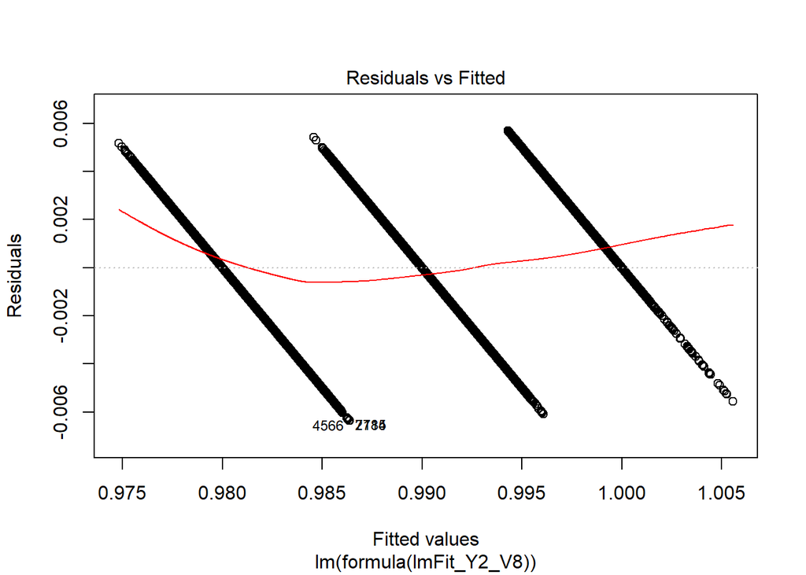

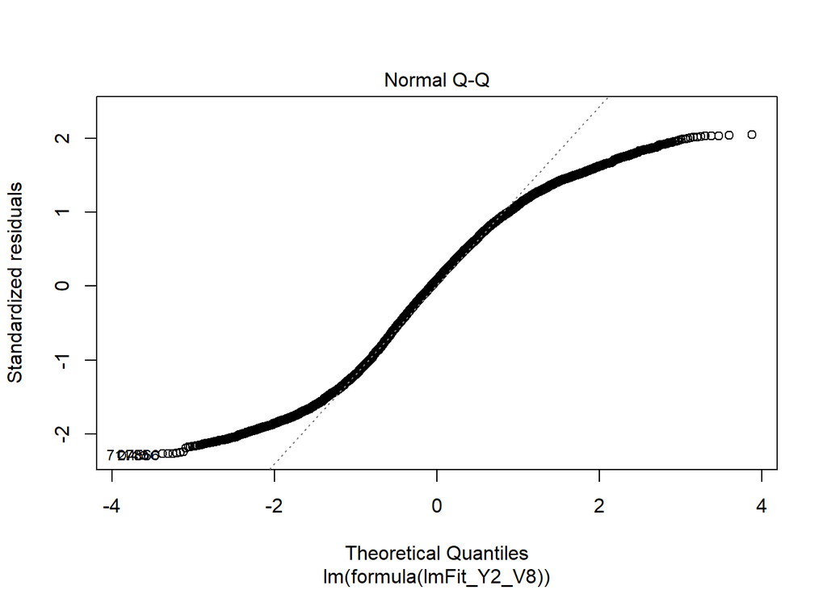

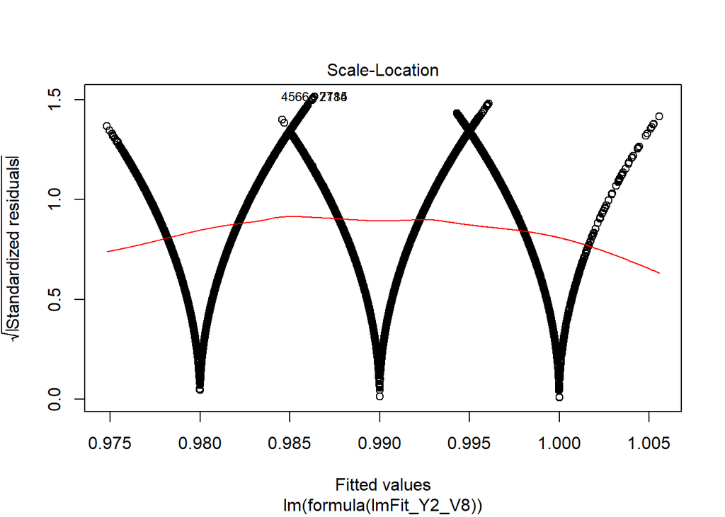

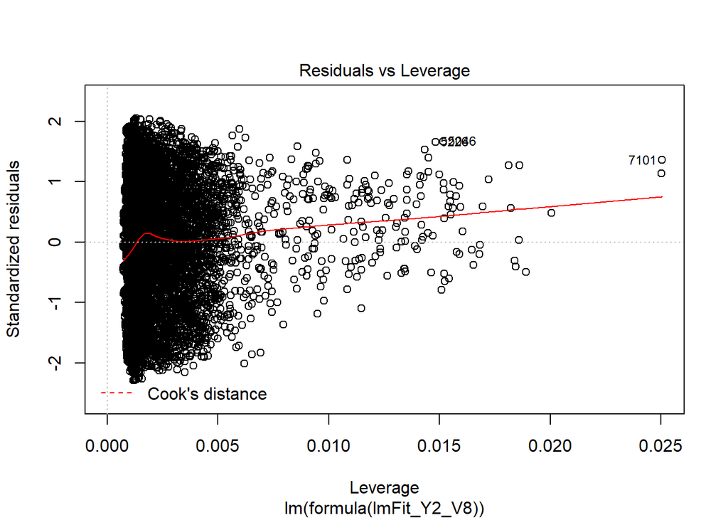

```r
plot(lmFitY2)
```

As we can see, all remaining variables are highly significant, and the Adjusted R-squared has increased to a final value of 0.8702

### Prediction of Y1 and Y2 in the Pred dataset

First, we will have to read in the predicted data given. This will be used for our confidence and prediction intervals.

```r
navalDataPred <- read.csv("assign1_NavalPred.csv", header = TRUE)
```

In this section, we will be predicting 2 intervals, Confidence and Prediction. Confidence interval shows how much the model can vary, and prediction interval shows how much the prediction can vary. In these 2 tables, we will see the **fit, upper and lower limits** of the prediction.

```r
predict(lmFitY1, navalDataPred, interval = "confidence", level = 0.95)
```

```
##            fit       lwr       upr
## 1    0.9813531 0.9811436 0.9815626
## 2    0.9681227 0.9677443 0.9685011
## 3    0.9639922 0.9637328 0.9642517
## 4    0.9549926 0.9547822 0.9552031
## 5    0.9885903 0.9883463 0.9888343
## 6    0.9985176 0.9982721 0.9987630
## 7    0.9894982 0.9892770 0.9897193
## 8    0.9632651 0.9630568 0.9634733
## 9    0.9515607 0.9511507 0.9519708
## 10   0.9806934 0.9803161 0.9810707
## 11   0.9961388 0.9956611 0.9966164
## 12   0.9887639 0.9885717 0.9889561
## 13   0.9480860 0.9478586 0.9483134
## 14   0.9571991 0.9569954 0.9574028
```

[output cut: 986 more lines]

```r
predict(lmFitY1, navalDataPred, interval = "prediction", level = 0.95)
```

```
##            fit       lwr       upr
## 1    0.9813531 0.9747860 0.9879202
## 2    0.9681227 0.9615480 0.9746974
## 3    0.9639922 0.9574233 0.9705611
## 4    0.9549926 0.9484255 0.9615598
## 5    0.9885903 0.9820220 0.9951586
## 6    0.9985176 0.9919492 1.0050859
## 7    0.9894982 0.9829307 0.9960656
## 8    0.9632651 0.9566980 0.9698322
## 9    0.9515607 0.9449842 0.9581373
## 10   0.9806934 0.9741188 0.9872680
## 11   0.9961388 0.9895576 1.0027199
## 12   0.9887639 0.9821973 0.9953304
## 13   0.9480860 0.9415183 0.9546537
## 14   0.9571991 0.9506322 0.9637660
```

[output cut: 986 more lines]

Here are the standard errors of coefficients

```r
coef(summary(lmFitY1))
```

```
##                  Estimate   Std. Error    t value      Pr(>|t|)
## (Intercept)  1.557500e+01 1.342152e-01 116.045051  0.000000e+00
## X1           2.172138e-01 3.443395e-03  63.081281  0.000000e+00
## X2          -6.502026e-02 1.087746e-03 -59.775200  0.000000e+00
## X3          -2.086156e-05 3.354441e-07 -62.190862  0.000000e+00
## X5           1.509502e-04 1.075810e-06 140.313066  0.000000e+00
## X6           1.361380e-03 3.439867e-05  39.576536 3.954106e-317
## X8           8.290942e-03 1.835918e-04  45.159642  0.000000e+00
## X10         -4.264548e-02 5.673897e-04 -75.160820  0.000000e+00
## X11          1.517706e-01 4.687655e-03  32.376650 3.428508e-218
## X13          3.374938e-02 5.922875e-04  56.981417  0.000000e+00
## X14         -3.741609e+00 4.049072e-02 -92.406577  0.000000e+00
## X15         -1.258907e-02 4.452083e-04 -28.276810 6.118517e-169
## X16         -1.486990e-01 1.084888e-02 -13.706390  2.355986e-42
## I(X10^2)     3.308307e-05 6.753851e-07  48.984010  0.000000e+00
## I(X8^2)     -7.188467e-07 8.585073e-08  -8.373216  6.403349e-17
## I(X15^2)    -3.232914e-05 1.157412e-06 -27.932250 4.711742e-165
## X8:X10      -9.660356e-06 4.568642e-07 -21.144918  5.259941e-97
## X10:X15      2.045540e-05 1.009987e-06  20.253145  2.558915e-89
## X8:X15       1.644176e-06 3.240721e-07   5.073490  3.980001e-07
```

Confidence Intervals of coefficients

```r
confint(lmFitY1)
```

```
##                     2.5 %        97.5 %
## (Intercept)  1.531191e+01  1.583810e+01
## X1           2.104640e-01  2.239635e-01
## X2          -6.715248e-02 -6.288804e-02
## X3          -2.151910e-05 -2.020401e-05
## X5           1.488414e-04  1.530591e-04
## X6           1.293951e-03  1.428809e-03
## X8           7.931062e-03  8.650821e-03
## X10         -4.375768e-02 -4.153327e-02
## X11          1.425817e-01  1.609594e-01
## X13          3.258837e-02  3.491039e-02
## X14         -3.820980e+00 -3.662239e+00
## X15         -1.346178e-02 -1.171637e-02
## X16         -1.699651e-01 -1.274329e-01
## I(X10^2)     3.175917e-05  3.440697e-05
## I(X8^2)     -8.871326e-07 -5.505609e-07
## I(X15^2)    -3.459791e-05 -3.006036e-05
## X8:X10      -1.055591e-05 -8.764804e-06
## X10:X15      1.847561e-05  2.243519e-05
## X8:X15       1.008926e-06  2.279427e-06
```

Variance of residuals

```r
var(lmFitY1$residuals)
```

```
## [1] 1.119113e-05
```

Here, we will be plotting `Y1` against the variable with the highest correlation with `Y1`, which is `X10`

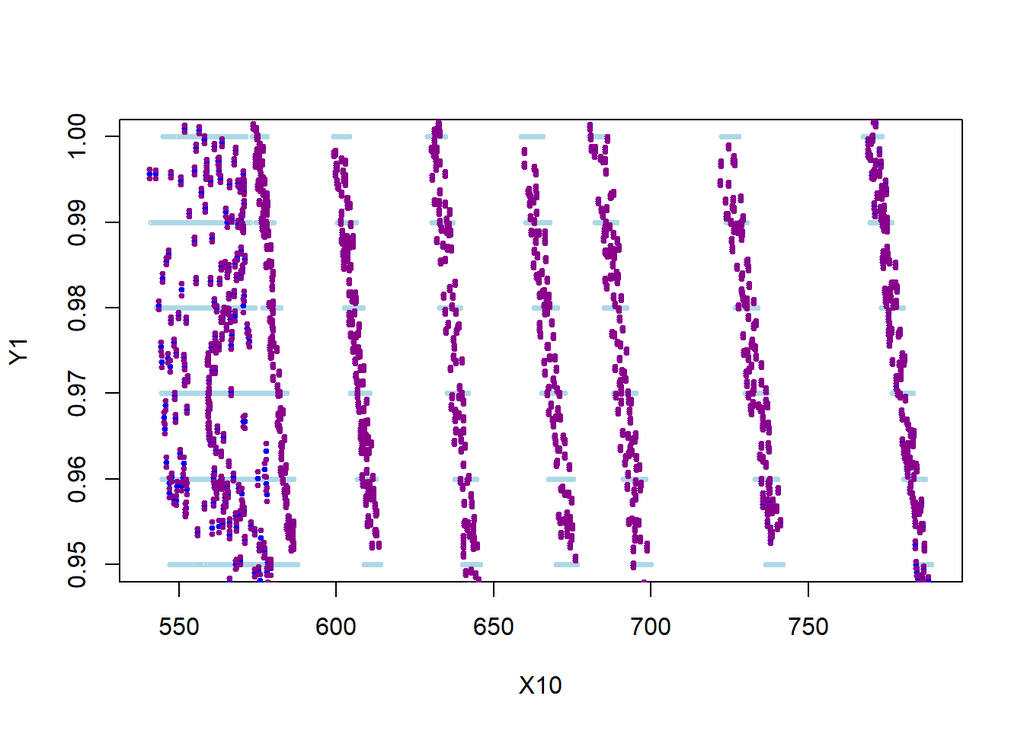

```r
plot(navalDataRevised$X10, navalDataRevised$Y1,
     pch = 21, col = "lightblue", cex = 0.5,
     xlab = "X10", ylab = "Y1")
predictionY1 <- predict(lmFitY1, newdata = navalDataPred)
points(navalDataPred$X10, predictionY1, col = "blue", cex = 0.5, pch = 19)

confint <- predict(lmFitY1, newdata = navalDataPred, interval = "confidence", level = 0.95)
points(navalDataPred$X10, confint[,2], col = "brown4", cex = 0.5, pch = 19)
points(navalDataPred$X10, confint[,3], col = "brown4", cex = 0.5, pch = 19)

predint <- predict(lmFitY1, newdata = navalDataPred, interval = "prediction", level = 0.95)
points(navalDataPred$X10, confint[,2], col = "darkmagenta", cex = 0.5, pch = 19)
points(navalDataPred$X10, confint[,3], col = "darkmagenta", cex = 0.5, pch = 19)
```

As we can see from the plot diagram, there will be very little variance as we are using our best model.

Now, we will move onto predicting on `Y2`

```r
predict(lmFitY2, navalDataPred, interval = "confidence", level = 0.95)
```

```
##            fit       lwr       upr
## 1    0.9831846 0.9829975 0.9833718
## 2    0.9858633 0.9855390 0.9861875
## 3    0.9821268 0.9819088 0.9823449
## 4    0.9940411 0.9938457 0.9942364
## 5    0.9919577 0.9917620 0.9921533
## 6    0.9883171 0.9881141 0.9885200
## 7    0.9848078 0.9846105 0.9850052
## 8    0.9919247 0.9917310 0.9921184
## 9    0.9823448 0.9819986 0.9826909
## 10   0.9797744 0.9794740 0.9800749
## 11   0.9750383 0.9746884 0.9753883
## 12   0.9894034 0.9892157 0.9895910
## 13   0.9785849 0.9783657 0.9788042
## 14   0.9927612 0.9925747 0.9929477
```

[output cut: 986 more lines]

```r
predict(lmFitY2, navalDataPred, interval = "prediction", level = 0.95)
```

```
##            fit       lwr       upr
## 1    0.9831846 0.9777346 0.9886347
## 2    0.9858633 0.9804068 0.9913197
## 3    0.9821268 0.9766757 0.9875780
## 4    0.9940411 0.9885908 0.9994914
## 5    0.9919577 0.9865073 0.9974080
## 6    0.9883171 0.9828665 0.9937676
## 7    0.9848078 0.9793575 0.9902582
## 8    0.9919247 0.9864744 0.9973749
## 9    0.9823448 0.9768870 0.9878026
## 10   0.9797744 0.9743193 0.9852295
## 11   0.9750383 0.9695803 0.9804964
## 12   0.9894034 0.9839533 0.9948534
## 13   0.9785849 0.9731337 0.9840362
## 14   0.9927612 0.9873112 0.9982112
```

[output cut: 986 more lines]

Here are the standard errors of coefficients

```r
coef(summary(lmFitY2))
```

```
##                  Estimate   Std. Error    t value      Pr(>|t|)
## (Intercept)  5.023419e-01 4.414710e-02  11.378821  8.303413e-30
## X1           2.933107e-02 3.515615e-04  83.430837  0.000000e+00
## X3           2.241162e-05 3.417000e-07  65.588588  0.000000e+00
## X4           8.385035e-05 2.449040e-06  34.238051 2.169350e-242
## X5           3.391048e-05 1.059983e-06  31.991527 2.143569e-213
## X6          -2.413423e-03 3.651906e-05 -66.086672  0.000000e+00
## X8          -1.302219e-03 3.154511e-05 -41.281164  0.000000e+00
## X10          4.680443e-04 4.724604e-05   9.906529  5.038846e-23
## X11          1.333625e-01 6.508692e-03  20.489906  2.429252e-91
## X13         -1.995523e-01 3.269907e-03 -61.026885  0.000000e+00
## X14          9.096854e-01 3.391422e-02  26.823127 7.545260e-153
## X15          1.641228e-02 6.582135e-04  24.934587 5.444624e-133
## X16          3.683722e-01 2.556769e-02  14.407721  1.426948e-46
## I(X15^2)    -1.659771e-05 1.580077e-06 -10.504367  1.139204e-25
## I(X13^2)     3.475943e-03 1.120005e-04  31.035076 1.571600e-201
## I(X16^2)    -4.745119e-01 3.816338e-02 -12.433698  3.216968e-35
## X8:X15      -1.498133e-05 1.012905e-06 -14.790466  5.885764e-49
## X8:X13       1.650193e-04 4.921388e-06  33.531053 4.252718e-233
## X8:X16      -7.202380e-04 5.800225e-05 -12.417415  3.930649e-35
## X13:X15     -1.902950e-03 5.864963e-05 -32.446080 3.896418e-219
## X15:X16      2.445527e-02 1.123047e-03  21.775815 1.223752e-102
```

Confidence Intervals of coefficients

```r
confint(lmFitY2)
```

```
##                     2.5 %        97.5 %
## (Intercept)  4.158042e-01  5.888797e-01
## X1           2.864194e-02  3.002021e-02
## X3           2.174181e-05  2.308142e-05
## X4           7.904971e-05  8.865099e-05
## X5           3.183268e-05  3.598827e-05
## X6          -2.485008e-03 -2.341838e-03
## X8          -1.364054e-03 -1.240384e-03
## X10          3.754320e-04  5.606566e-04
## X11          1.206041e-01  1.461209e-01
## X13         -2.059620e-01 -1.931425e-01
## X14          8.432063e-01  9.761645e-01
## X15          1.512204e-02  1.770252e-02
## X16          3.182541e-01  4.184903e-01
## I(X15^2)    -1.969500e-05 -1.350042e-05
## I(X13^2)     3.256398e-03  3.695488e-03
## I(X16^2)    -5.493202e-01 -3.997035e-01
## X8:X15      -1.696684e-05 -1.299582e-05
## X8:X13       1.553723e-04  1.746663e-04
## X8:X16      -8.339348e-04 -6.065412e-04
## X13:X15     -2.017916e-03 -1.787985e-03
## X15:X16      2.225386e-02  2.665668e-02
```

Variance of residuals

```r
var(lmFitY2$residuals)
```

```
## [1] 7.704873e-06
```

Here, we will be plotting `Y2` against the variable with the highest correlation with `Y2`, which is `X8`

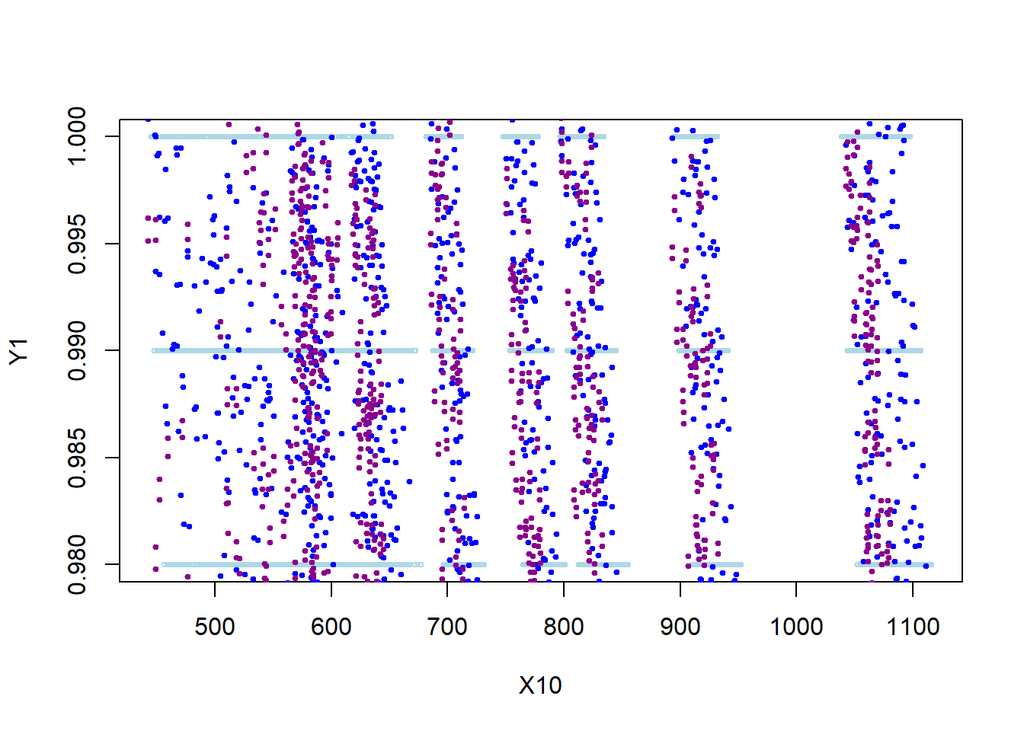

```r
plot(navalDataRevised$X8, navalDataRevised$Y2,
     pch = 21, col = "lightblue", cex = 0.5,
     xlab = "X10", ylab = "Y1")

predictionY2 <- predict(lmFitY2, newdata = navalDataPred)
points(navalDataPred$X8, predictionY2, col = "blue", cex = 0.5, pch = 19)

confint <- predict(lmFitY1, newdata = navalDataPred, interval = "confidence", level = 0.95)
points(navalDataPred$X8, confint[,2], col = "brown4", cex = 0.5, pch = 19)
points(navalDataPred$X8, confint[,3], col = "brown4", cex = 0.5, pch = 19)

predint <- predict(lmFitY1, newdata = navalDataPred, interval = "prediction", level = 0.95)
points(navalDataPred$X8, confint[,2], col = "darkmagenta", cex = 0.5, pch = 19)
points(navalDataPred$X8, confint[,3], col = "darkmagenta", cex = 0.5, pch = 19)
```

### Prediction values of Y1 and Y2

For the prediction accuracy of `Y1` and `Y2`, we will be using **Root Mean Squared Error (RMSE)**. RMSE is a function that gives extra weight to outliers of the dataset.

Prediction accuracy of `Y1`

```r
Y1sum <- sum((lmFitY1$residuals)^2)/nrow(navalDataRevisedY1.clean)
Y1root <- sqrt(Y1sum)
Y1root
```

```
## [1] 0.003345139
```

As we can see, the **RMSE** of `Y1` after fitting our best model and removing outliers is a very small value of 0.003345139.

Prediction accuracy of `Y2`

```r
Y2sum <- sum((lmFitY2$residuals)^2)/nrow(navalDataRevisedY2.clean)
Y2root <- sqrt(Y2sum)
Y2root
```

```
## [1] 0.00277562
```

As we can see, the **RMSE** of `Y2` after fitting our best model and removing outliers is a very small value of 0.00277562.

### Additional parts for Assignment

**Performance of Y1** Initial “total sum of squares” of errors

```r
mean(navalData$Y1)
```

```
## [1] 0.975662
```

```r
sum((navalData$Y1 - mean(navalData$Y1))^2)
```

```
## [1] 2.336418
```

Final “residual sum of squares” of errors

```r
lmFitY1$residuals
```

[output not shown]

[output cut: 3739 more lines]

[output not shown]

```r
sum(lmFitY1$residuals^2)
```

```
## [1] 0.1061255
```

```r
summary(lmFitY1$residuals)
```

```
##      Min.   1st Qu.    Median      Mean   3rd Qu.      Max.
## -0.008928 -0.002530 -0.000010  0.000000  0.002567  0.008524
```

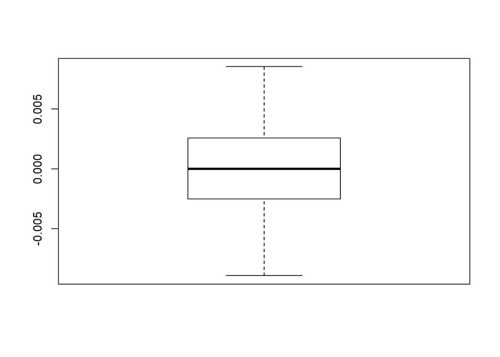

```r
boxplot(lmFitY1$residuals)
```

No outliners found on the boxplot.

Improvement of the sum of squares

```r
TSS_Y1 <- sum((navalData$Y1 - mean(navalData$Y1))^2)
RSS_Y1 <- sum(lmFitY1$residuals^2)
```

This is precisely “Multiple R-squared”

```r
(TSS_Y1 - RSS_Y1) / TSS_Y1
```

```
## [1] 0.9545777
```

Root Mean Squared Error

```r
MSE_Y1 <- RSS_Y1/nrow(navalDataRevisedY1.clean)
RMSE_Y1 <- sqrt(MSE_Y1)
RMSE_Y1
```

```
## [1] 0.003345139
```

Compare with the first Linear Model

```r
RSS_1 <- sum(lmFit_Y1_V1$residuals^2)
MSE_1 <- RSS_1/nrow(within(navalData, rm(Y2)))
RMSE_1 <- sqrt(MSE_1)
RMSE_1
```

```
## [1] 0.006117947
```

**Performance of Y2**

Initial “total sum of squares” of errors

```r
mean(navalData$Y2)
```

```
## [1] 0.98845
```

```r
sum((navalData$Y2 - mean(navalData$Y2))^2)
```

```
## [1] 0.594975
```

Final “residual sum of squares” of errors

```r
lmFitY2$residuals
```

[output not shown]

[output cut: 3763 more lines]

[output not shown]

```r
sum(lmFitY2$residuals^2)
```

```
## [1] 0.07350448
```

```r
summary(lmFitY2$residuals)
```

```
##      Min.   1st Qu.    Median      Mean   3rd Qu.      Max.
## -0.006370 -0.002230  0.000223  0.000000  0.002302  0.005694
```

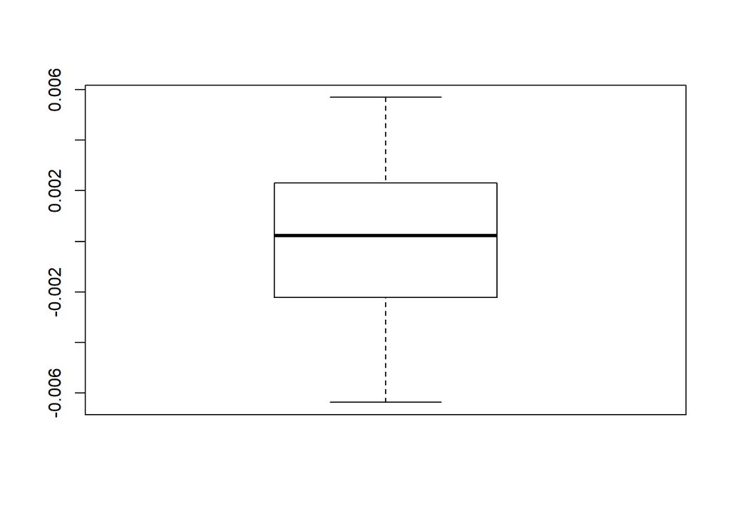

```r
boxplot(lmFitY2$residuals)
```

No outliners found on the boxplot.

Improvement of the sum of squares

```r
TSS_Y2 <- sum((navalData$Y2 - mean(navalData$Y2))^2)
RSS_Y2 <- sum(lmFitY2$residuals^2)
```

```r
(TSS_Y2 - RSS_Y2) / TSS_Y2
```

```
## [1] 0.8764579
```

Root Mean Squared Error

```r
MSE_Y2 <- RSS_Y2/nrow(navalDataRevisedY2.clean)
RMSE_Y2 <- sqrt(MSE_Y2)
RMSE_Y2
```

```
## [1] 0.00277562
```

Compare with the first Linear Model

```r
RSS_2 <- sum(lmFit_Y2_V1$residuals^2)
MSE_2 <- RSS_2/nrow(within(navalData, rm(Y1)))
RMSE_2 <- sqrt(MSE_2)
RMSE_2
```

```
## [1] 0.00354747
```

End of Assignment 1